# Final_Project_Full_Code_Notebook_EasyVisa

[figure not shown]

Data Science and Business Analytics

Ensemble Techniques and Model Tuning

[figure not shown]

Visa Approval Facilitation

# **Problem Statement**

## Context

Business communities in the United States are facing high demand for human resources, but one of the constant challenges is identifying and attracting the right talent, which is perhaps the most important element in remaining competitive. Companies in the United States look for hard-working, talented, and qualified individuals both locally as well as abroad.

The Immigration and Nationality Act (INA) of the US permits foreign workers to come to the United States to work on either a temporary or permanent basis. The act also protects US workers against adverse impacts on their wages or working conditions by ensuring US employers' compliance with statutory requirements when they hire foreign workers to fill workforce shortages. The immigration programs are administered by the Office of Foreign Labor Certification (OFLC).

OFLC processes job certification applications for employers seeking to bring foreign workers into the United States and grants certifications in those cases where employers can demonstrate that there are not sufficient US workers available to perform the work at wages that meet or exceed the wage paid for the occupation in the area of intended employment.

## Objective

In FY 2016, the OFLC processed 775,979 employer applications for 1,699,957 positions for temporary and permanent labor certifications. This was a nine percent increase in the overall number of processed applications from the previous year. The process of reviewing every case is becoming a tedious task as the number of applicants is increasing every year.

The increasing number of applicants every year calls for a Machine Learning based solution that can help in shortlisting the candidates having higher chances of VISA approval. OFLC has hired the firm EasyVisa for data-driven solutions. You as a data scientist at EasyVisa have to analyze the data provided and, with the help of a classification model:

- Facilitate the process of visa approvals.
- Recommend a suitable profile for the applicants for whom the visa should be certified or denied based on the drivers that significantly influence the case status.

## Data Description

The data contains the different attributes of employee and the employer. The detailed data dictionary is given below.

- case_id: ID of each visa application
- continent: Information of continent the employee
- education_of_employee: Information of education of the employee
- has_job_experience: Does the employee has any job experience? Y= Yes; N = No
- requires_job_training: Does the employee require any job training? Y = Yes; N = No
- no_of_employees: Number of employees in the employer's company
- yr_of_estab: Year in which the employer's company was established
- region_of_employment: Information of foreign worker's intended region of employment in the US.
- prevailing_wage: Average wage paid to similarly employed workers in a specific occupation in the area of intended employment. The purpose of the prevailing wage is to ensure that the foreign worker is not underpaid compared to other workers offering the same or similar service in the same area of employment.
- unit_of_wage: Unit of prevailing wage. Values include Hourly, Weekly, Monthly, and Yearly.
- full_time_position: Is the position of work full-time? Y = Full Time Position; N = Part Time Position
- case_status: Flag indicating if the Visa was certified or denied

## Note: This is a sample solution for the project. Projects will NOT be graded on the basis of how well the submission matches this sample solution. Projects will be graded on the basis of the rubric only.

# **Importing necessary libraries**

```python
# Installing the libraries required for this project.
#!pip install xgboost
#!pip install imblearn
```

**Note**: *After running the above cell, kindly restart the notebook kernel and run all cells sequentially from the start again.*

```python
import warnings

warnings.filterwarnings("ignore")

# Libraries to help with reading and manipulating data
import numpy as np
import pandas as pd

# Library to split data
from sklearn.model_selection import train_test_split

# libaries to help with data visualization
import matplotlib.pyplot as plt
import seaborn as sns

# Removes the limit for the number of displayed columns
pd.set_option("display.max_columns", None)
# Sets the limit for the number of displayed rows
pd.set_option("display.max_rows", 100)

# To oversample and undersample data
from imblearn.over_sampling import SMOTE
from imblearn.under_sampling import RandomUnderSampler

# Libraries different ensemble classifiers
from sklearn.ensemble import (
    BaggingClassifier,
    RandomForestClassifier,
    AdaBoostClassifier,
    GradientBoostingClassifier,
    StackingClassifier,
)

from xgboost import XGBClassifier
from sklearn.tree import DecisionTreeClassifier

# Libraries to get different metric scores
from sklearn import metrics
from sklearn.metrics import (
    confusion_matrix,
    accuracy_score,
    precision_score,
    recall_score,
    f1_score,
)

# To tune different models
from sklearn.model_selection import GridSearchCV
```

```python
%matplotlib inline
```

# **Loading the dataset**

```python
df_visa = pd.read_csv("EasyVisa.csv")
```

# **Overview of the Dataset**

- Observations
- Sanity checks

The initial steps to get an overview of any dataset is to:

- observe the first few rows of the dataset, to check whether the dataset has been loaded properly or not
- get information about the number of rows and columns in the dataset
- find out the data types of the columns to ensure that data is stored in the preferred format and the value of each property is as expected.
- check the statistical summary of the dataset to get an overview of the numerical columns of the data

```python
df_visa.head()
```

|  | case_id | continent | education_of_employee | has_job_experience | requires_job_training | no_of_employees | yr_of_estab | region_of_employment | prevailing_wage | unit_of_wage | full_time_position | case_status |
| --- | --- | --- | --- | --- | --- | --- | --- | --- | --- | --- | --- | --- |
| 0 | EZYV01 | Asia | High School | N | N | 14513 | 2007 | West | 592.2029 | Hour | Y | Denied |
| 1 | EZYV02 | Asia | Master's | Y | N | 2412 | 2002 | Northeast | 83425.6500 | Year | Y | Certified |
| 2 | EZYV03 | Asia | Bachelor's | N | Y | 44444 | 2008 | West | 122996.8600 | Year | Y | Denied |
| 3 | EZYV04 | Asia | Bachelor's | N | N | 98 | 1897 | West | 83434.0300 | Year | Y | Denied |
| 4 | EZYV05 | Africa | Master's | Y | N | 1082 | 2005 | South | 149907.3900 | Year | Y | Certified |

```python
df_visa.tail()
```

|  | case_id | continent | education_of_employee | has_job_experience | requires_job_training | no_of_employees | yr_of_estab | region_of_employment | prevailing_wage | unit_of_wage | full_time_position | case_status |
| --- | --- | --- | --- | --- | --- | --- | --- | --- | --- | --- | --- | --- |
| 25475 | EZYV25476 | Asia | Bachelor's | Y | Y | 2601 | 2008 | South | 77092.57 | Year | Y | Certified |
| 25476 | EZYV25477 | Asia | High School | Y | N | 3274 | 2006 | Northeast | 279174.79 | Year | Y | Certified |
| 25477 | EZYV25478 | Asia | Master's | Y | N | 1121 | 1910 | South | 146298.85 | Year | N | Certified |
| 25478 | EZYV25479 | Asia | Master's | Y | Y | 1918 | 1887 | West | 86154.77 | Year | Y | Certified |
| 25479 | EZYV25480 | Asia | Bachelor's | Y | N | 3195 | 1960 | Midwest | 70876.91 | Year | Y | Certified |

```python
# check shape of visa dataset
df_visa.shape
```

```
(25480, 12)
```

```python
# Check the data types of the columns for the visa dataset
df_visa.info()
```

```
<class 'pandas.core.frame.DataFrame'>
RangeIndex: 25480 entries, 0 to 25479
Data columns (total 12 columns):
 #   Column                 Non-Null Count  Dtype
---  ------                 --------------  -----
 0   case_id                25480 non-null  object
 1   continent              25480 non-null  object
 2   education_of_employee  25480 non-null  object
 3   has_job_experience     25480 non-null  object
 4   requires_job_training  25480 non-null  object
 5   no_of_employees        25480 non-null  int64
 6   yr_of_estab            25480 non-null  int64
 7   region_of_employment   25480 non-null  object
 8   prevailing_wage        25480 non-null  float64
 9   unit_of_wage           25480 non-null  object
 10  full_time_position     25480 non-null  object
 11  case_status            25480 non-null  object
dtypes: float64(1), int64(2), object(9)
memory usage: 2.3+ MB
```

```python
# check duplicates if any
df_visa.duplicated().sum()
```

```
0
```

```python
# check missing values if any
df_visa.isnull().sum()
```

```
case_id                  0
continent                0
education_of_employee    0
has_job_experience       0
requires_job_training    0
no_of_employees          0
yr_of_estab              0
region_of_employment     0
prevailing_wage          0
unit_of_wage             0
full_time_position       0
case_status              0
dtype: int64
```

```python
# Statistical summarry on the numerical dataset
df_visa.describe().T
```

|  | count | mean | std | min | 25% | 50% | 75% | max |
| --- | --- | --- | --- | --- | --- | --- | --- | --- |
| no_of_employees | 25480.0 | 5667.043210 | 22877.928848 | -26.0000 | 1022.00 | 2109.00 | 3504.0000 | 602069.00 |
| yr_of_estab | 25480.0 | 1979.409929 | 42.366929 | 1800.0000 | 1976.00 | 1997.00 | 2005.0000 | 2016.00 |
| prevailing_wage | 25480.0 | 74455.814592 | 52815.942327 | 2.1367 | 34015.48 | 70308.21 | 107735.5125 | 319210.27 |

### Observations

- `case_id`, `continent`, `education_of_employee`, `has_job_experience`, `requires_job_training`, `region_of_employment`, `unit_of_wage`, `full_time_position` and `case_status` is a string object.
- `case_status` takes the two values as `Certified` or `Denied` - this can be considered as a categorical variable and may be imputed as `ZERO` as `Denied` / `ONE` as `Certified`
- `no_of_employees`, `yr_of_estab` is of type integer
- `prevailing_wage` is of type float
- Need to build a model for `case_status` a.k.a can be `Y target`
- All other columns OR features from `machine learning perpective`, can be referred as `features variable`

### Sanity checks

- There are no duplicates.
- There are no missing values, that means missing values treatment may not be required before building up the model

### Statistical summary

- On an average `no_of_employees` are in the range of 2k with max of 602k employees
- `minimum` `no_of_employes` is -26, which doesn't make sense so we may need to check the data
- On an average `prevailing_wage` is ~ 70k with the max of 319k
- `minimum` `prevailing_wage` is 2 , which doesn't make sense so we may need to check the data
- 'yr_of_estab` should not be integer as its representing the year, so we need to check the dtype here and see if any conversion is required

# **Exploratory Data Analysis (EDA)**

- EDA is an important part of any project involving data.
- It is important to investigate and understand the data better before building a model with it.
- A few questions have been mentioned below which will help you approach the analysis in the right manner and generate insights from the data.
- A thorough analysis of the data, in addition to the questions mentioned below, should be done.

**Leading Questions**

What is the distribution of visa case statuses (certified vs. denied)?

1. What is the distribution of visa case statuses (certified vs. denied)?
2. How does the education level of employees impact visa approval rates?
3. Is there a significant difference in visa approval rates between employees with and without prior job experience?
4. How does the prevailing wage affect visa approval? Do higher wages lead to higher chances of approval?
5. Do certain regions in the US have higher visa approval rates compared to others?
6. How does the number of employees in a company influence visa approval? Do larger companies have a higher approval rate?
7. Are visa approval rates different across various continents of employees? Which continent has the highest and lowest approval rates?

## Perform Univariate analysis

- Based on the data type - float64/int64, draw the histogram/boxplot.
  - `no_of_employees`
  - `yr_of_estab`
  - `prevailing_wage`
- Based on the data type - Object, draw the barplot.
  - `case_id`
  - `continent`
  - `education_of_employee`
  - `has_job_experience`
  - `requires_job_training`
  - `region_of_employment`
  - `unit_of_wage`
  - `full_time_position`
  - `case_status`

**`Method` commonly used to draw histogram and box plot together and get crisp visuals designed for `numerical` variables**

```python
# Reusable code
# Visualize both the histogram and box plot for each variable to gain clear insights into the data distribution and characteristics.

def histogram_boxplot(data, feature, figsize=(15, 10), kde=False, bins=None):
    """
    Boxplot and histogram combined

    data: dataframe
    feature: dataframe column
    figsize: size of figure (default (15,10))
    kde: whether to show the density curve (default False)
    bins: number of bins for histogram (default None)
    """
    f2, (ax_box2, ax_hist2) = plt.subplots(
        nrows=2,  # Number of rows of the subplot grid= 2
        sharex=True,  # x-axis will be shared among all subplots
        gridspec_kw={"height_ratios": (0.25, 0.75)},
        figsize=figsize,
    )  # creating the 2 subplots
    sns.boxplot(
        data=data, x=feature, ax=ax_box2, showmeans=True, color="violet"
    )  # boxplot will be created and a triangle will indicate the mean value of the column
    sns.histplot(
        data=data, x=feature, kde=kde, ax=ax_hist2, bins=bins
    ) if bins else sns.histplot(
        data=data, x=feature, kde=kde, ax=ax_hist2
    )  # For histogram
    ax_hist2.axvline(
        data[feature].mean(), color="green", linestyle="--"
    )  # Add mean to the histogram
    ax_hist2.axvline(
        data[feature].median(), color="black", linestyle="-"
    )  # Add median to the histogram
```

**Method commonly used to draw bar plot and get crisp visuals - designed for `categeorical` variables**

```python
# Reusable code
# Visualize the bar plot for each variable to gain clear insights into the data characteristics.

# function to create labeled barplots


def labeled_barplot(data, feature, perc=False, n=None):
    """
    Barplot with percentage at the top

    data: dataframe
    feature: dataframe column
    perc: whether to display percentages instead of count (default is False)
    n: displays the top n category levels (default is None, i.e., display all levels)
    """

    total = len(data[feature])  # length of the column
    count = data[feature].nunique()
    if n is None:
        plt.figure(figsize=(count + 2, 6))
    else:
        plt.figure(figsize=(n + 2, 6))

    plt.xticks(rotation=90, fontsize=15)
    ax = sns.countplot(
        data=data,
        x=feature,
        order=data[feature].value_counts().index[:n],
    )

    for p in ax.patches:
        if perc == True:
            label = "{:.1f}%".format(
                100 * p.get_height() / total
            )  # percentage of each class of the category
        else:
            label = p.get_height()  # count of each level of the category

        x = p.get_x() + p.get_width() / 2  # width of the plot
        y = p.get_height()  # height of the plot

        ax.annotate(
            label,
            (x, y),
            ha="center",
            va="center",
            size=12,
            xytext=(0, 5),
            textcoords="offset points",
        )  # annotate the percentage

    plt.show()  # show the plot
```

#### Data analysis for all numerical columns to understand

- Outliers
- Data distribution

`no_of_employees`

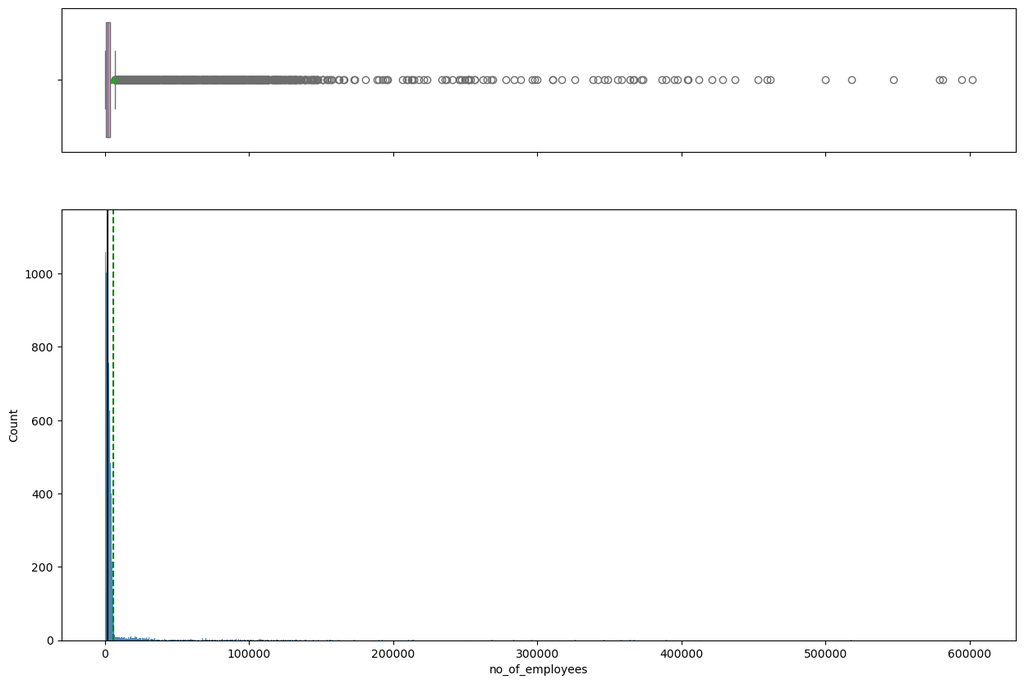

```python
histogram_boxplot(df_visa, "no_of_employees")
```

```python
df_visa["no_of_employees"].value_counts()
```

```
no_of_employees
183      18
854      16
724      16
766      15
1476     15
         ..
5876      1
5536      1
47866     1
4700      1
40224     1
Name: count, Length: 7105, dtype: int64
```

```python
df_visa["no_of_employees"].describe()
```

```
count     25480.000000
mean       5667.043210
std       22877.928848
min         -26.000000
25%        1022.000000
50%        2109.000000
75%        3504.000000
max      602069.000000
Name: no_of_employees, dtype: float64
```

- Mean (green line) is greater than median (black line) - indicate data distibution is highly right skewed.
- Its evident based on the histogram and boxplot
- There are many outliers on right side of the whisker, Nax is trending towards 600,000 employees. No of employee -26 does not make sense.

Let's continue to analyze ...

`yr_of_estab`

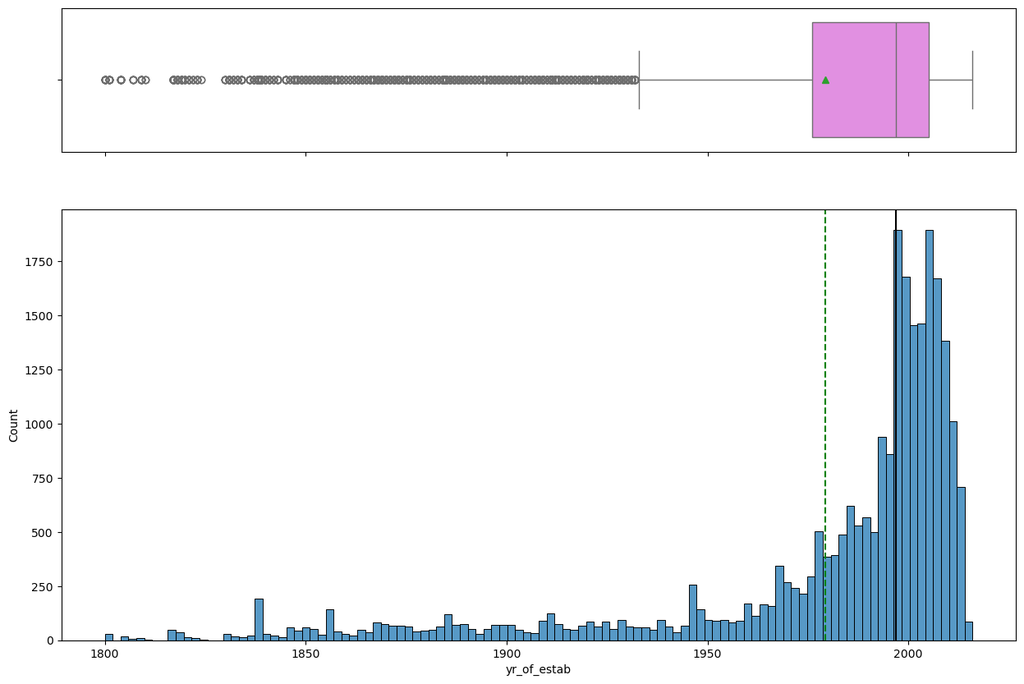

```python
histogram_boxplot(df_visa, "yr_of_estab")
```

```python
df_visa["yr_of_estab"].value_counts()
```

```
yr_of_estab
1998    1134
2005    1051
2001    1017
2007     994
1999     870
        ...
1842       6
1846       4
1822       4
1810       3
1824       2
Name: count, Length: 199, dtype: int64
```

- Mean (green line) is less than median (black line) - indicate data distibution is highly left skewed.
- Its evident based on the histogram and boxplot
- There are many outliers on left side of the whisker.

Let's continue to analyze ...

`prevailing_wage`

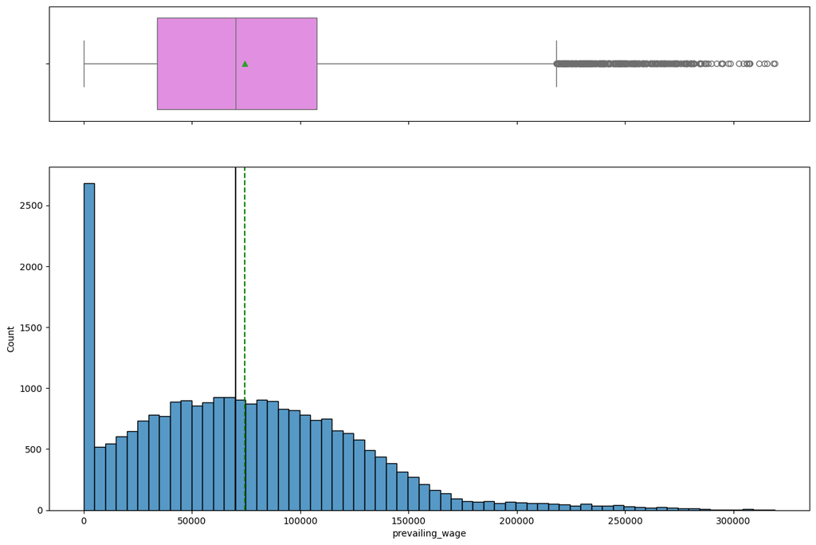

```python
histogram_boxplot(df_visa, "prevailing_wage")
```

```python
df_visa["prevailing_wage"].value_counts()
```

```
prevailing_wage
82560.2800     2
122.6500       2
60948.1500     2
64357.5800     2
108.1200       2
              ..
25713.9800     1
101656.6400    1
65665.5500     1
50.8813        1
70876.9100     1
Name: count, Length: 25454, dtype: int64
```

```python
df_visa["prevailing_wage"].describe()
```

```
count     25480.000000
mean      74455.814592
std       52815.942327
min           2.136700
25%       34015.480000
50%       70308.210000
75%      107735.512500
max      319210.270000
Name: prevailing_wage, dtype: float64
```

- Mean (green line) is greater than median (black line) - indicate data distibution is right skewed.
- Its evident based on the histogram and boxplot
- There are many outliers on right side of the whisker.

Let's continue to analyze ...

`case_id`

case_id is used to keep track of number of cases in the dataset. this field can be ignored, infact before building up the model, this field will be removed from the dataset

`continent`

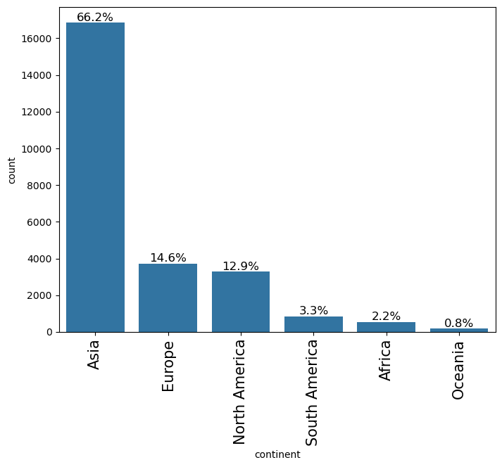

```python
labeled_barplot(df_visa, "continent", perc=True)
```

```python
df_visa["continent"].value_counts()
```

```
continent
Asia             16861
Europe            3732
North America     3292
South America      852
Africa             551
Oceania            192
Name: count, dtype: int64
```

- Asia is contributing to maximum number of applications, 66.2% overall and total of 16,861 applications followed by Europe and North America

Let's continue to analyze ...

`education_of_employee`

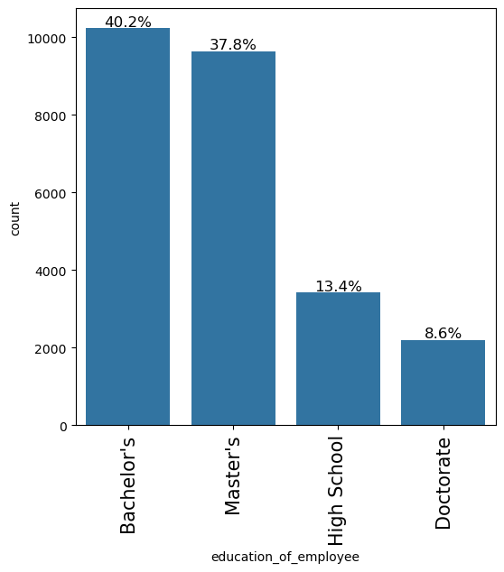

```python
labeled_barplot(df_visa, "education_of_employee", perc=True)
```

```python
df_visa["education_of_employee"].value_counts()
```

```
education_of_employee
Bachelor's     10234
Master's        9634
High School     3420
Doctorate       2192
Name: count, dtype: int64
```

- Bachelor's contributing to maximum number of applications, 40.2% overall and total of 10,234 applications followed by Master;s and High School

Let's continue to analyze ...

`has_job_experience`

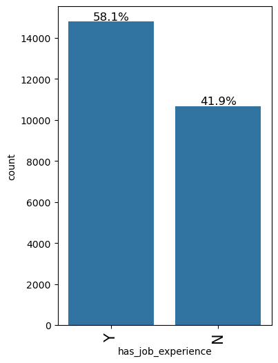

```python
labeled_barplot(df_visa, "has_job_experience", perc=True)
```

```python
df_visa["has_job_experience"].value_counts()
```

```
has_job_experience
Y    14802
N    10678
Name: count, dtype: int64
```

- 58% applicants have job experience and 42% have no job experience

Let's continue to analyze ...

`requires_job_training`

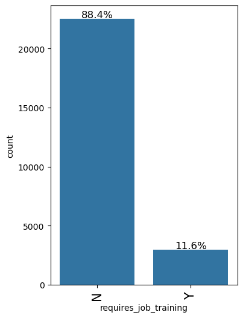

```python
labeled_barplot(df_visa, "requires_job_training", perc=True)
```

```python
df_visa["requires_job_training"].value_counts()
```

```
requires_job_training
N    22525
Y     2955
Name: count, dtype: int64
```

- 88.4% applicants do not require training and 11.6% do require

Let's continue to analyze ...

`region_of_employment`

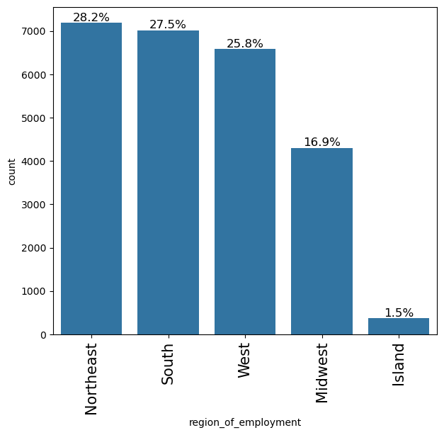

```python
labeled_barplot(df_visa, "region_of_employment", perc=True)
```

```python
df_visa["region_of_employment"].value_counts()
```

```
region_of_employment
Northeast    7195
South        7017
West         6586
Midwest      4307
Island        375
Name: count, dtype: int64
```

Let's continue to analyze ...

`unit_of_wage`

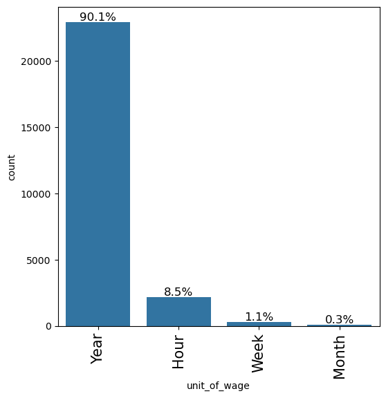

```python
labeled_barplot(df_visa, "unit_of_wage", perc=True)
```

```python
df_visa["unit_of_wage"].value_counts()
```

```
unit_of_wage
Year     22962
Hour      2157
Week       272
Month       89
Name: count, dtype: int64
```

- 90% wage are yearly which make sense. There are 8.5% hourly wage, very few % on monthly wage.

Let's continue to analyze ...

`full_time_position`

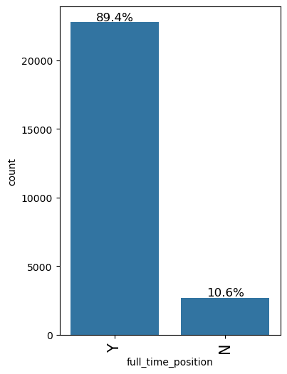

```python
labeled_barplot(df_visa, "full_time_position", perc=True)
```

```python
df_visa["full_time_position"].value_counts()
```

```
full_time_position
Y    22773
N     2707
Name: count, dtype: int64
```

- 90% positions are full time which make sense, followed by 10% positions which are not offered full time

Let's continue to analyze ...

`case_status`

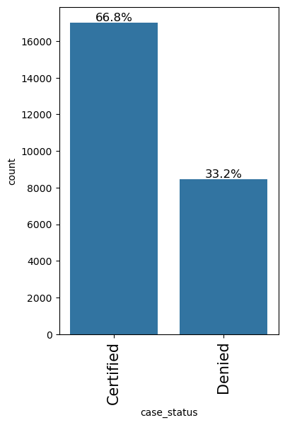

```python
labeled_barplot(df_visa, "case_status", perc=True)
```

```python
df_visa["case_status"].value_counts()
```

```
case_status
Certified    17018
Denied        8462
Name: count, dtype: int64
```

- 66.8% applications certified and 33.2% applications denied

**Univariate Analysis Summary**

- There are outliers in the features `no_of_employees`, `yr_of_estab`, and `prevailing_wage`.  
  We may need to consider whether imputation or transformation is appropriate for these values.
- The remaining features appear to have reasonable distributions, with no obvious data anomalies detected at this stage.

## Bivariate Analysis

```python
df_visa_attr = df_visa.iloc[:, 0:11]
print(df_visa_attr.dtypes)
```

```
case_id                   object
continent                 object
education_of_employee     object
has_job_experience        object
requires_job_training     object
no_of_employees            int64
yr_of_estab                int64
region_of_employment      object
prevailing_wage          float64
unit_of_wage              object
full_time_position        object
dtype: object
```

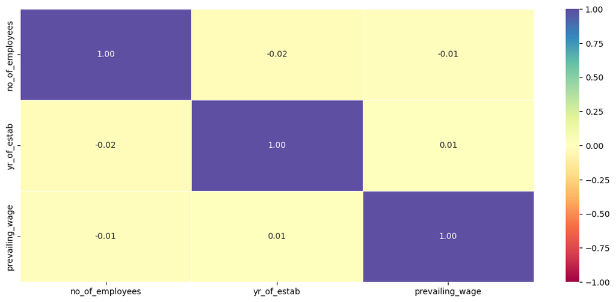

```python
# create heatmap to understand correlation strength between all the x variables
num_cols = df_visa.select_dtypes(include=np.number).columns.tolist()

# Set larger figure size
plt.figure(figsize=(14, 6))

sns.heatmap(
    df_visa[num_cols].corr(), annot=True, vmin=-1, vmax=1, fmt=".2f", cmap="Spectral", linewidths=0.5, linecolor='white'
)
plt.show()
```

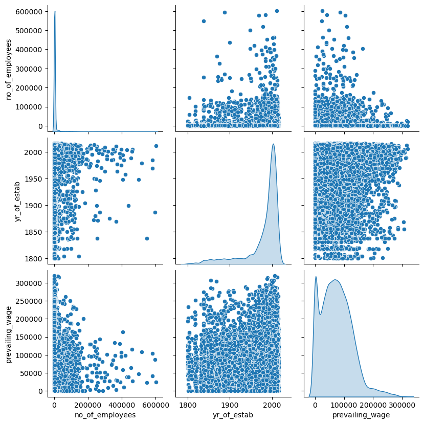

```python
sns.pairplot(df_visa, diag_kind="kde", height=2.8)
plt.show()
```

- No linear relationship between the independent variables and its expected. This is a classification problem and is a sigmoid function.

## Based on the Data Analysis done above, I'll try to answer the questions being asked. As required, more analysis may be needed to answer few questions and I will elaborate more as I continue to seek answers

**Leading Questions**

1. What is the distribution of visa case statuses (certified vs. denied)?
2. How does the education level of employees impact visa approval rates?
3. Is there a significant difference in visa approval rates between employees with and without prior job experience?
4. How does the prevailing wage affect visa approval? Do higher wages lead to higher chances of approval?
5. Do certain regions in the US have higher visa approval rates compared to others?
6. How does the number of employees in a company influence visa approval? Do larger companies have a higher approval rate?
7. Are visa approval rates different across various continents of employees? Which continent has the highest and lowest approval rates?
1. What is the distribution of visa case statuses (certified vs. denied)?

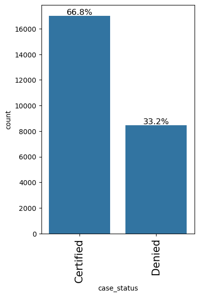

```python
labeled_barplot(df_visa, "case_status", perc=True)
```

- 66.8% applications certified and 33.2% applications denied
2. How does the education level of employees impact visa approval rates?

```
Crosstab: Percentage of Visa Case Status by Education Level
Case Status      Certified  Denied
Education Level
Bachelor's           62.21   37.79
Doctorate            87.23   12.77
High School          34.04   65.96
Master's             78.63   21.37
```

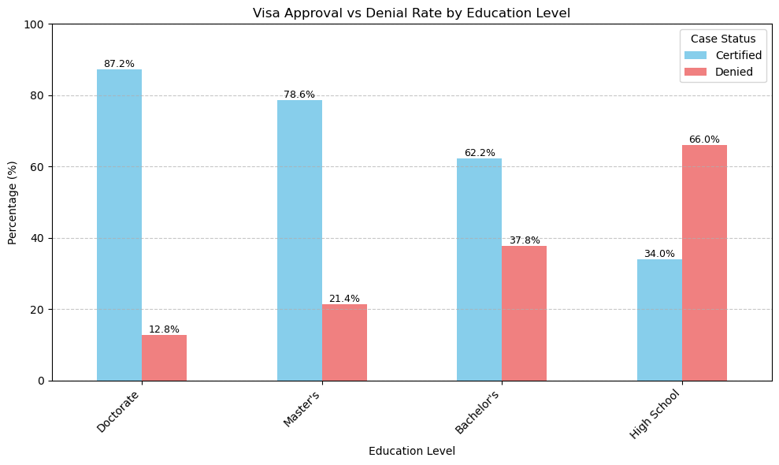

```python
# Step 1: Crosstab with percentage of case_status within each education level
education_impact = pd.crosstab(
    df_visa["education_of_employee"],
    df_visa["case_status"],
    normalize='index'
) * 100

education_impact = education_impact.round(2)
education_impact.columns.name = "Case Status"
education_impact.index.name = "Education Level"

print("Crosstab: Percentage of Visa Case Status by Education Level")
print(education_impact)

# Step 2: Prepare Certified and Denied rates as a new DataFrame for plotting
plot_data = education_impact[["Certified", "Denied"]].copy()
plot_data = plot_data.sort_values(by="Certified", ascending=False)

# Step 3: Grouped bar plot (side-by-side)
ax = plot_data.plot(kind='bar', figsize=(10, 6), color=['skyblue', 'lightcoral'])

# Add percentage labels on top of each bar
for container in ax.containers:
    ax.bar_label(container, fmt='%.1f%%', label_type='edge', fontsize=9)

# Final plot formatting
plt.title('Visa Approval vs Denial Rate by Education Level')
plt.ylabel('Percentage (%)')
plt.xlabel('Education Level')
plt.xticks(rotation=45, ha='right')
plt.ylim(0, 100)
plt.grid(axis='y', linestyle='--', alpha=0.7)
plt.tight_layout()
plt.legend(title='Case Status')
plt.show()
```

- Higher the education, more likely chances of visa approvals
- This is evident by the bar graph. Doctorate, followed by Masters, followed by Bachelors and at last high school
3. Is there a significant difference in visa approval rates between employees with and without prior job experience?

```
Crosstab: Percentage of Visa Case Status by Job experience
Case Status     Certified  Denied
Job Experience
N                   56.13   43.87
Y                   74.48   25.52
```

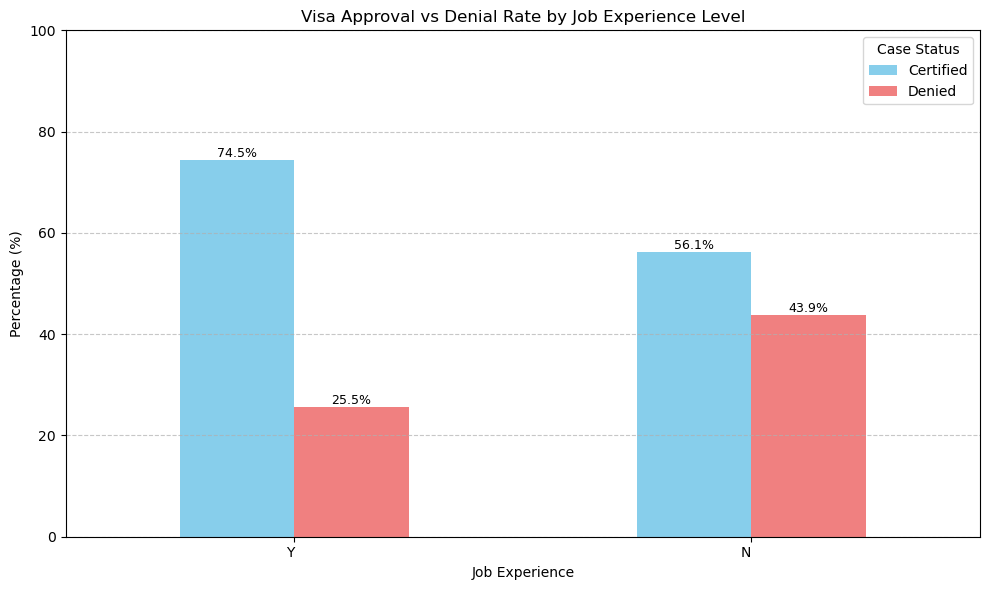

```python
# Step 1: Crosstab with percentage of case_status within each job experience level
job_experience_impact = pd.crosstab(
    df_visa["has_job_experience"],
    df_visa["case_status"],
    normalize='index'
) * 100

job_experience_impact = job_experience_impact.round(2)
job_experience_impact.columns.name = "Case Status"
job_experience_impact.index.name = "Job Experience"

print("Crosstab: Percentage of Visa Case Status by Job experience")
print(job_experience_impact)

# Step 2: Prepare Certified and Denied rates as a new DataFrame for plotting
plot_data = job_experience_impact[["Certified", "Denied"]].copy()
plot_data = plot_data.sort_values(by="Certified", ascending=False)

# Step 3: Grouped bar plot (side-by-side)
ax = plot_data.plot(kind='bar', figsize=(10, 6), color=['skyblue', 'lightcoral'])

# Add percentage labels on top of each bar
for container in ax.containers:
    ax.bar_label(container, fmt='%.1f%%', label_type='edge', fontsize=9)

# Final plot formatting
plt.title('Visa Approval vs Denial Rate by Job Experience Level')
plt.ylabel('Percentage (%)')
plt.xlabel('Job Experience')
plt.xticks(rotation=0, ha='right')
plt.ylim(0, 100)
plt.grid(axis='y', linestyle='--', alpha=0.7)
plt.tight_layout()
plt.legend(title='Case Status')
plt.show()
```

- With job experience 'Y', approval rate is higher. With no job experience, deniel rate is higher.
- This is evident by the bar graph.
4. How does the prevailing wage affect visa approval? Do higher wages lead to higher chances of approval?

```python
def distribution_plot(data, predictor, target):
    """
    Plots histogram and boxplots of a predictor variable grouped by target.

    Parameters:
    - data: pandas DataFrame
    - predictor: str, column name for the predictor variable
    - target: str, column name for the target variable
    """

    target_vals = data[target].unique()
    fig, axs = plt.subplots(2, 2, figsize=(12, 10))

    # Histograms for each target value
    colors = ['teal', 'orange']
    for i, val in enumerate(target_vals[:2]):
        sns.histplot(
            data=data[data[target] == val],
            x=predictor,
            kde=True,
            stat='density',
            color=colors[i % len(colors)],
            ax=axs[0, i]
        )
        axs[0, i].set_title(f"Distribution for {target} = {val}")

    # Boxplots
    sns.boxplot(data=data, x=target, y=predictor, ax=axs[1, 0], palette='Set2')
    axs[1, 0].set_title("Boxplot by Target")

    sns.boxplot(data=data, x=target, y=predictor, ax=axs[1, 1], showfliers=False, palette='Set2')
    axs[1, 1].set_title("Boxplot (No Outliers) by Target")

    plt.tight_layout()
    plt.show()
```

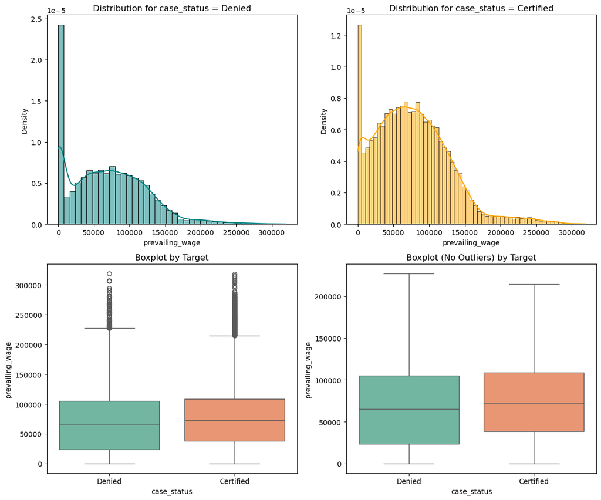

```python
distribution_plot(df_visa, "prevailing_wage", "case_status")
```

**Denial cases**

- Sharp peak near zero suggests many denied cases involve very low wages.
- There’s also a smaller hump between 40k-100k, indicating some denials happen even at mid-level wages.
- Long right tail indicates that a few denials occurred even at high salaries (200K+), though they’re rare.

```
Crosstab: Percentage of Visa Case Status by Region of Employment
Case Status           Certified  Denied
Region of Employment
Island                    60.27   39.73
Midwest                   75.53   24.47
Northeast                 62.90   37.10
South                     70.02   29.98
West                      62.25   37.75
```

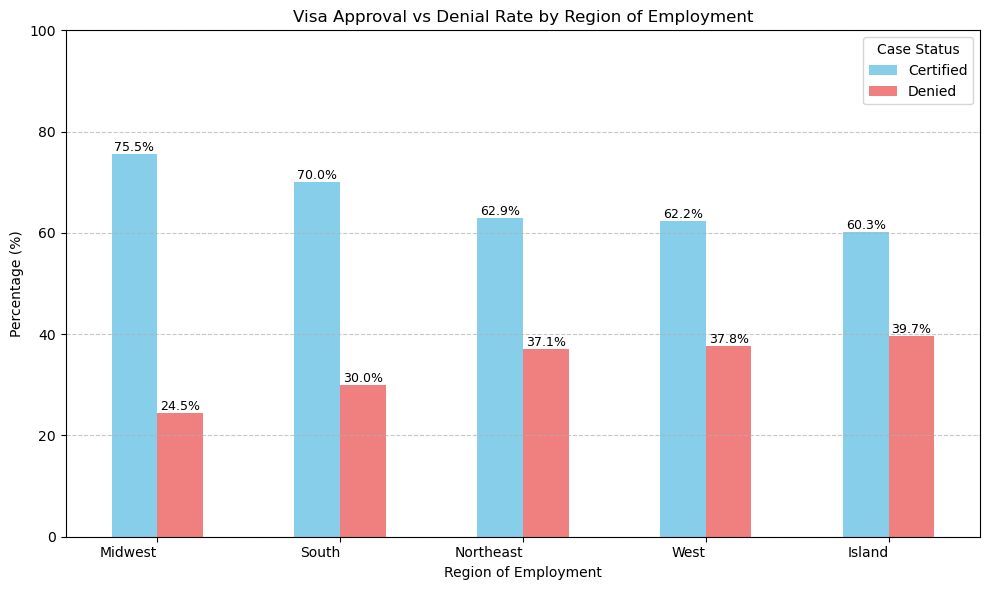

```python
# Step 1: Crosstab with percentage of case_status within each Region of Employment
region_of_employment_impact = pd.crosstab(
    df_visa["region_of_employment"],
    df_visa["case_status"],
    normalize='index'
) * 100

region_of_employment_impact = region_of_employment_impact.round(2)
region_of_employment_impact.columns.name = "Case Status"
region_of_employment_impact.index.name = "Region of Employment"

print("Crosstab: Percentage of Visa Case Status by Region of Employment")
print(region_of_employment_impact)

# Step 2: Prepare Certified and Denied rates as a new DataFrame for plotting
plot_data = region_of_employment_impact[["Certified", "Denied"]].copy()
plot_data = plot_data.sort_values(by="Certified", ascending=False)

# Step 3: Grouped bar plot (side-by-side)
ax = plot_data.plot(kind='bar', figsize=(10, 6), color=['skyblue', 'lightcoral'])

# Add percentage labels on top of each bar
for container in ax.containers:
    ax.bar_label(container, fmt='%.1f%%', label_type='edge', fontsize=9)

# Final plot formatting
plt.title('Visa Approval vs Denial Rate by Region of Employment')
plt.ylabel('Percentage (%)')
plt.xlabel('Region of Employment')
plt.xticks(rotation=0, ha='right')
plt.ylim(0, 100)
plt.grid(axis='y', linestyle='--', alpha=0.7)
plt.tight_layout()
plt.legend(title='Case Status')
plt.show()
```

- Data shows that regions like Midwest and South have higher visa approval rates compare other regions.
- Rejections rate are higher for West and Island region
6. How does the number of employees in a company influence visa approval? Do larger companies have a higher approval rate?

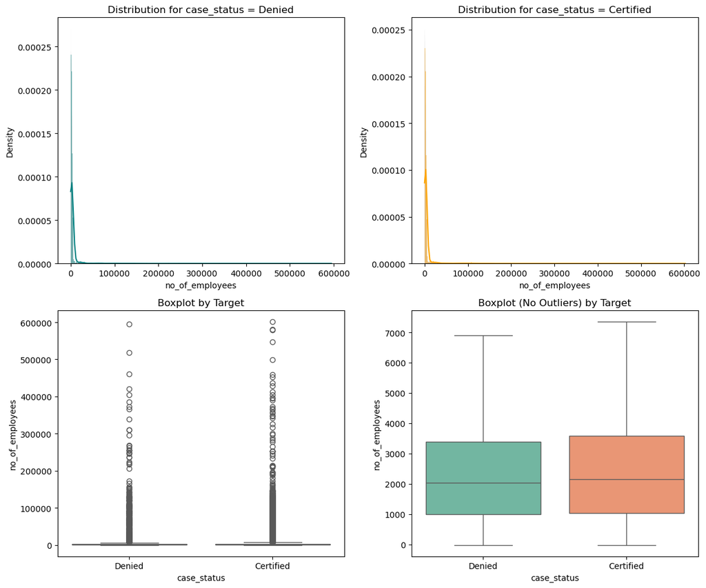

```python
distribution_plot(df_visa, "no_of_employees", "case_status")
```

**Denied Cases**

- Most denials are associated with companies that have very few employees (the curve spikes near 0).
- Very long tail to the right: some large companies (up to 600,000 employees) also get denials, but these are rare.
- Skewed distribution: extreme right skew.

**Certified Cases**

- Sharp spike for small companies, long tail for large ones.
- Most visa certified and denied come from small companies (low employee count).
- Larger companies tend to have a slightly higher certification rate, as inferred from the slope in the Certified curve.
- Both distributions have many outliers (dots) at high employee counts.
- Median number of employees is similar for Certified and Denied.
- Denied cases have slightly tighter interquartile range (IQR).
- Median number of employees is higher for Certified cases.
- The overall range (max without outliers) is slightly wider for Certified cases.
- Box for Certified is shifted slightly higher, suggesting visa approval is more common among larger employers.
7. Are visa approval rates different across various continents of employees? Which continent has the highest and lowest approval rates?

```
Crosstab: Percentage of Visa Case Status by Continents
Case Status    Certified  Denied
Continents
Africa             72.05   27.95
Asia               65.31   34.69
Europe             79.23   20.77
North America      61.88   38.12
Oceania            63.54   36.46
South America      57.86   42.14
```

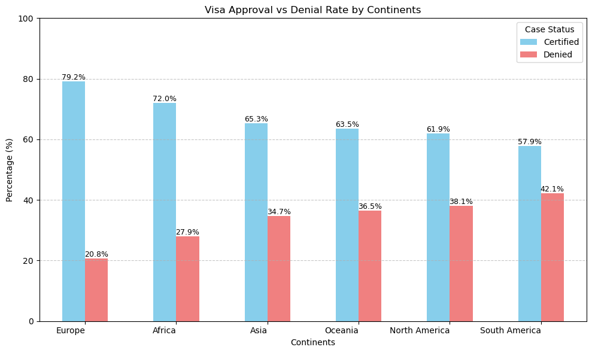

```python
# Step 1: Crosstab with percentage of case_status within each continents
continents_impact = pd.crosstab(
    df_visa["continent"],
    df_visa["case_status"],
    normalize='index'
) * 100

continents_impact = continents_impact.round(2)
continents_impact.columns.name = "Case Status"
continents_impact.index.name = "Continents"

print("Crosstab: Percentage of Visa Case Status by Continents")
print(continents_impact)

# Step 2: Prepare Certified and Denied rates as a new DataFrame for plotting
plot_data = continents_impact[["Certified", "Denied"]].copy()
plot_data = plot_data.sort_values(by="Certified", ascending=False)

# Step 3: Grouped bar plot (side-by-side)
ax = plot_data.plot(kind='bar', figsize=(10, 6), color=['skyblue', 'lightcoral'])

# Add percentage labels on top of each bar
for container in ax.containers:
    ax.bar_label(container, fmt='%.1f%%', label_type='edge', fontsize=9)

# Final plot formatting
plt.title('Visa Approval vs Denial Rate by Continents')
plt.ylabel('Percentage (%)')
plt.xlabel('Continents')
plt.xticks(rotation=0, ha='right')
plt.ylim(0, 100)
plt.grid(axis='y', linestyle='--', alpha=0.7)
plt.tight_layout()
plt.legend(title='Case Status')
plt.show()
```

# **Data Pre-processing**

- Missing value treatment (if needed)
- Feature engineering (if needed)
- Outlier detection and treatment (if needed)
- Preparing data for modeling
- Any other preprocessing steps (if needed)

**Missing value treatment (if needed)**

```python
# check missing values if any
df_visa.isnull().sum()
```

```
case_id                  0
continent                0
education_of_employee    0
has_job_experience       0
requires_job_training    0
no_of_employees          0
yr_of_estab              0
region_of_employment     0
prevailing_wage          0
unit_of_wage             0
full_time_position       0
case_status              0
dtype: int64
```

- There are no missing value in the data, so thats a good news :)

**Feature engineering (if needed)**

```python
df_visa.head()
```

|  | case_id | continent | education_of_employee | has_job_experience | requires_job_training | no_of_employees | yr_of_estab | region_of_employment | prevailing_wage | unit_of_wage | full_time_position | case_status |
| --- | --- | --- | --- | --- | --- | --- | --- | --- | --- | --- | --- | --- |
| 0 | EZYV01 | Asia | High School | N | N | 14513 | 2007 | West | 592.2029 | Hour | Y | Denied |
| 1 | EZYV02 | Asia | Master's | Y | N | 2412 | 2002 | Northeast | 83425.6500 | Year | Y | Certified |
| 2 | EZYV03 | Asia | Bachelor's | N | Y | 44444 | 2008 | West | 122996.8600 | Year | Y | Denied |
| 3 | EZYV04 | Asia | Bachelor's | N | N | 98 | 1897 | West | 83434.0300 | Year | Y | Denied |
| 4 | EZYV05 | Africa | Master's | Y | N | 1082 | 2005 | South | 149907.3900 | Year | Y | Certified |

**Build a classification model to**

- Facilitate the process of visa approvals.
- Recommend a suitable profile for the applicants for whom the visa should be certified or denied based on the drivers that significantly influence the case status.

Following feature variables (including the y predict aka `case_status`) are defined as string `Object`.

- `case_id`, `continent` , `education_of_employee`, `has_job_experienced`, `requires_job_training`, `region_of_employment`, `unit_of_wage`, `full_time_position`, and `case_status`.
- Lets fix this in few steps.
  1. Drop `case_id`
  2. Change dtype for `case_status`a.k.a 'y-predict' from string Object to Categeroy.
  3. For `case_status` - encode the values as `"Denied" : 0`, `"Certified" : 1`

```python
df_visa_filled = df_visa.copy()
df_visa_filled.drop("case_id", axis=1, inplace=True)
```

```python
df_visa_filled.head()
```

|  | continent | education_of_employee | has_job_experience | requires_job_training | no_of_employees | yr_of_estab | region_of_employment | prevailing_wage | unit_of_wage | full_time_position | case_status |
| --- | --- | --- | --- | --- | --- | --- | --- | --- | --- | --- | --- |
| 0 | Asia | High School | N | N | 14513 | 2007 | West | 592.2029 | Hour | Y | Denied |
| 1 | Asia | Master's | Y | N | 2412 | 2002 | Northeast | 83425.6500 | Year | Y | Certified |
| 2 | Asia | Bachelor's | N | Y | 44444 | 2008 | West | 122996.8600 | Year | Y | Denied |
| 3 | Asia | Bachelor's | N | N | 98 | 1897 | West | 83434.0300 | Year | Y | Denied |
| 4 | Africa | Master's | Y | N | 1082 | 2005 | South | 149907.3900 | Year | Y | Certified |

```python
# for case_status - change the values as "Certified" : 1, "Denied" : 0
replaceStatus = {"case_status" : {"Certified" : 1, "Denied" : 0 } }
if df_visa_filled["case_status"].dtype == 'object':
        df_visa_filled["case_status"] = pd.Categorical(df_visa_filled["case_status"])
df_visa_filled = df_visa_filled.replace(replaceStatus)
```

```python
df_visa_filled.head()
```

|  | continent | education_of_employee | has_job_experience | requires_job_training | no_of_employees | yr_of_estab | region_of_employment | prevailing_wage | unit_of_wage | full_time_position | case_status |
| --- | --- | --- | --- | --- | --- | --- | --- | --- | --- | --- | --- |
| 0 | Asia | High School | N | N | 14513 | 2007 | West | 592.2029 | Hour | Y | 0 |
| 1 | Asia | Master's | Y | N | 2412 | 2002 | Northeast | 83425.6500 | Year | Y | 1 |
| 2 | Asia | Bachelor's | N | Y | 44444 | 2008 | West | 122996.8600 | Year | Y | 0 |
| 3 | Asia | Bachelor's | N | N | 98 | 1897 | West | 83434.0300 | Year | Y | 0 |
| 4 | Africa | Master's | Y | N | 1082 | 2005 | South | 149907.3900 | Year | Y | 1 |

```python
df_visa.info()
```

```
<class 'pandas.core.frame.DataFrame'>
RangeIndex: 25480 entries, 0 to 25479
Data columns (total 12 columns):
 #   Column                 Non-Null Count  Dtype
---  ------                 --------------  -----
 0   case_id                25480 non-null  object
 1   continent              25480 non-null  object
 2   education_of_employee  25480 non-null  object
 3   has_job_experience     25480 non-null  object
 4   requires_job_training  25480 non-null  object
 5   no_of_employees        25480 non-null  int64
 6   yr_of_estab            25480 non-null  int64
 7   region_of_employment   25480 non-null  object
 8   prevailing_wage        25480 non-null  float64
 9   unit_of_wage           25480 non-null  object
 10  full_time_position     25480 non-null  object
 11  case_status            25480 non-null  object
dtypes: float64(1), int64(2), object(9)
memory usage: 2.3+ MB
```

```python
df_visa_filled.info()
```

```
<class 'pandas.core.frame.DataFrame'>
RangeIndex: 25480 entries, 0 to 25479
Data columns (total 11 columns):
 #   Column                 Non-Null Count  Dtype
---  ------                 --------------  -----
 0   continent              25480 non-null  object
 1   education_of_employee  25480 non-null  object
 2   has_job_experience     25480 non-null  object
 3   requires_job_training  25480 non-null  object
 4   no_of_employees        25480 non-null  int64
 5   yr_of_estab            25480 non-null  int64
 6   region_of_employment   25480 non-null  object
 7   prevailing_wage        25480 non-null  float64
 8   unit_of_wage           25480 non-null  object
 9   full_time_position     25480 non-null  object
 10  case_status            25480 non-null  category
dtypes: category(1), float64(1), int64(2), object(7)
memory usage: 2.0+ MB
```

**Outlier detection and treatment (if needed)**

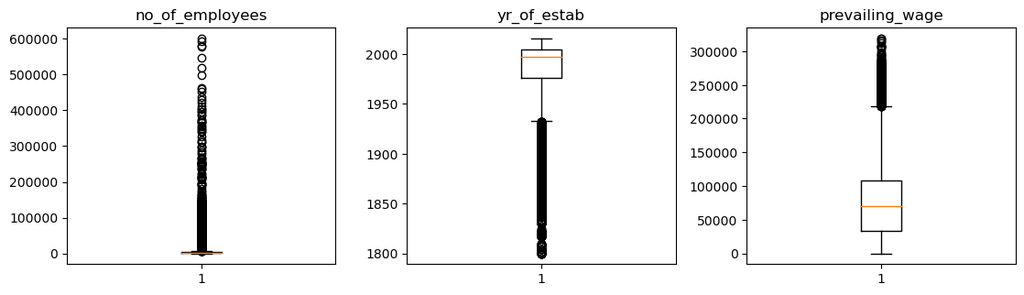

```python
numeric_columns = df_visa_filled.select_dtypes(include=np.number).columns.tolist()

plt.figure(figsize=(15, 12))

for i, variable in enumerate(numeric_columns):
    plt.subplot(4, 4, i + 1)
    plt.boxplot(df_visa_filled[variable], whis=1.5)
    plt.tight_layout()
    plt.title(variable)

plt.show()
```

**`No-of_employees`, `prevailing_wage` and `yr_of_estab` have lots of outliers**

- lets align the far left and far right outliers with lower whisker and uppoer whisker to stereamline the edge cases. it may further help creating the base model as well.

**Outlier treatment for `no_of_employees`**

```python
# Lets cap the outliers to lower and upper whiskers for edge cases - outliers far right and far left
Q1 = df_visa_filled["no_of_employees"].quantile(0.25)
Q3 = df_visa_filled["no_of_employees"].quantile(0.75)
IQR = Q3 - Q1
# Calculating value of upper whisker
upper_whisker = Q3 + 1.5 * IQR
# Calculating value of lower whisker
lower_whisker = Q1 - 1.5 * IQR
#assigning the outliers the value of upper_whisker or lower_whisker accordingly
df_visa_filled.loc[df_visa_filled["no_of_employees"] < lower_whisker, "no_of_employees"] = lower_whisker
df_visa_filled.loc[df_visa_filled["no_of_employees"] > upper_whisker, "no_of_employees"] = upper_whisker
```

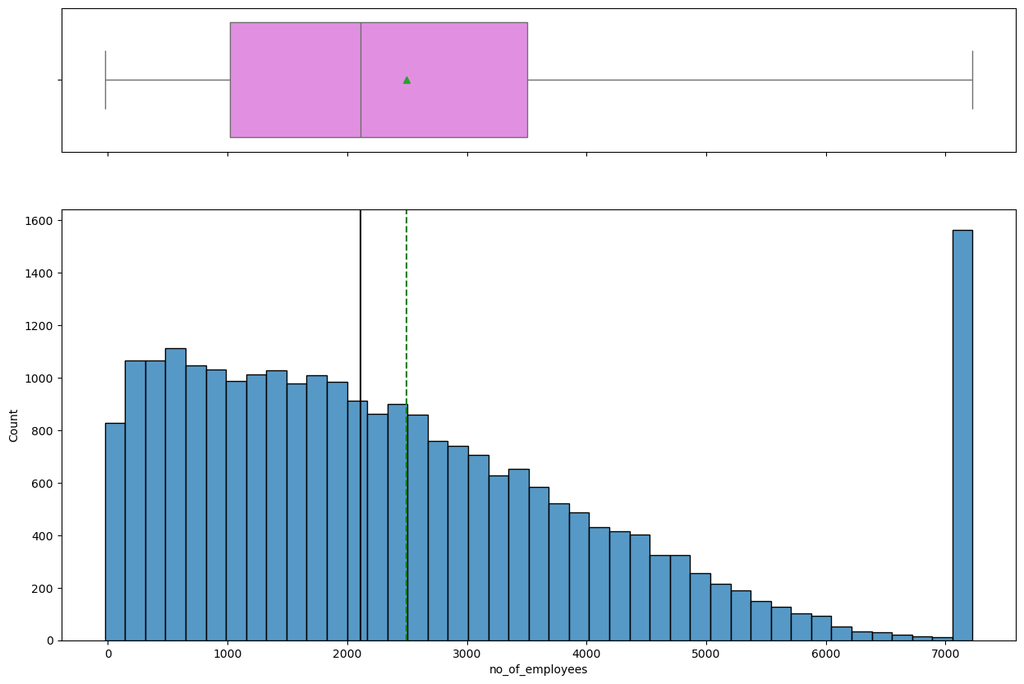

```python
histogram_boxplot(df_visa_filled, "no_of_employees")
```

- The whiskers now stop at a capped range, with no extreme dots/outliers beyond the upper end or at the lower end.
- The distribution looks much tighter and cleaner

**Outlier treatment for `prevailing_wage`**

```python
# Lets cap the outliers to lower and upper whiskers for edge cases - outliers far right and far left
Q1 = df_visa_filled["prevailing_wage"].quantile(0.25)
Q3 = df_visa_filled["prevailing_wage"].quantile(0.75)
IQR = Q3 - Q1
# Calculating value of upper whisker
upper_whisker = Q3 + 1.5 * IQR
# Calculating value of lower whisker
lower_whisker = Q1 - 1.5 * IQR
#assigning the outliers the value of upper_whisker or lower_whisker accordingly
df_visa_filled.loc[df_visa_filled["prevailing_wage"] < lower_whisker, "prevailing_wage"] = lower_whisker
df_visa_filled.loc[df_visa_filled["prevailing_wage"] > upper_whisker, "prevailing_wage"] = upper_whisker
```

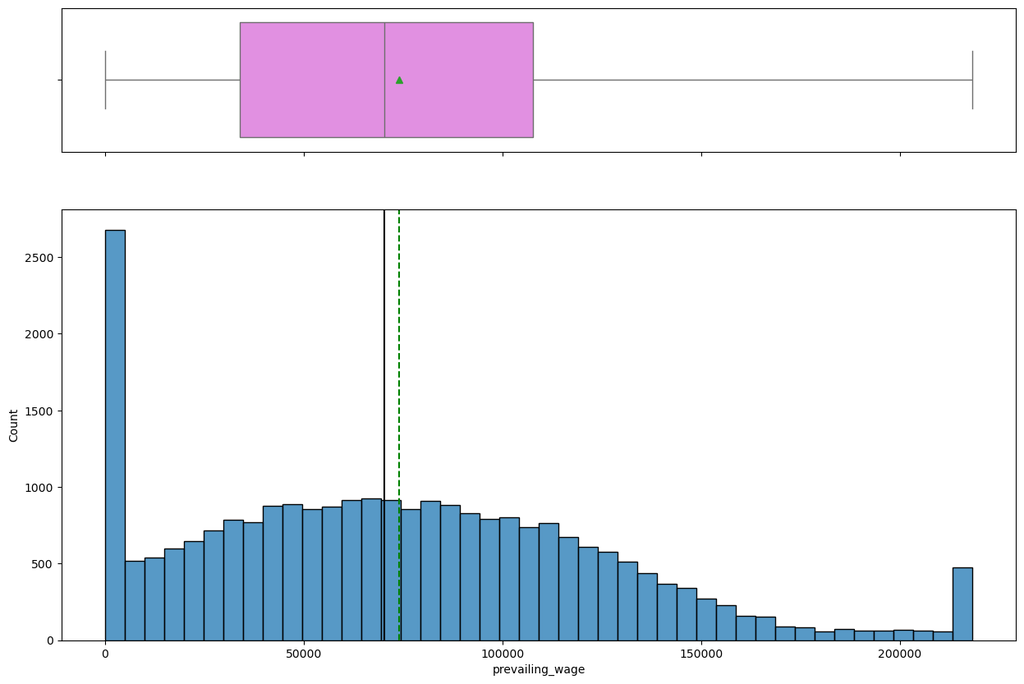

```python
histogram_boxplot(df_visa_filled, "prevailing_wage")
```

- The whiskers now stop at a capped range, with no extreme dots/outliers beyond the upper end or at the lower end.
- The distribution looks much tighter and cleaner

**Outlier treatment for `yr_of_estab`**

```python
df_visa_filled["yr_of_estab"].describe()
```

```
count    25480.000000
mean      1979.409929
std         42.366929
min       1800.000000
25%       1976.000000
50%       1997.000000
75%       2005.000000
max       2016.000000
Name: yr_of_estab, dtype: float64
```

- The bulk of companies were established between 1976 and 2005.
- A few companies have values as early as 1800, which is over 175 years older than the lower quartile.

```python
# Lets cap the outliers to lower and upper whiskers for edge cases - outliers far right and far left
Q1 = df_visa_filled["yr_of_estab"].quantile(0.25)
Q3 = df_visa_filled["yr_of_estab"].quantile(0.75)
IQR = Q3 - Q1
# Calculating value of upper whisker
upper_whisker = Q3 + 1.5 * IQR
# Calculating value of lower whisker
lower_whisker = Q1 - 1.5 * IQR
#assigning the outliers the value of upper_whisker or lower_whisker accordingly
df_visa_filled.loc[df_visa_filled["yr_of_estab"] < lower_whisker, "yr_of_estab"] = lower_whisker
df_visa_filled.loc[df_visa_filled["yr_of_estab"] > upper_whisker, "yr_of_estab"] = upper_whisker
```

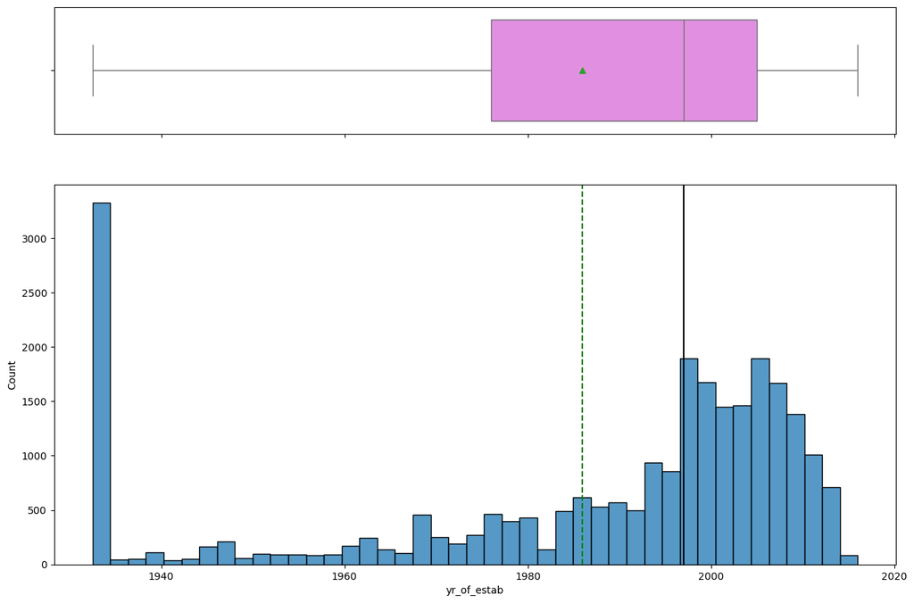

```python
histogram_boxplot(df_visa_filled, "yr_of_estab")
```

- The whiskers now stop at a capped range, with no extreme dots/outliers beyond the upper end or at the lower end.
- The distribution looks much tighter and cleaner

**Lets check the box plots for all 3 feature variables - `No-of_employees`, `prevailing_wage` and `yr_of_estab`**

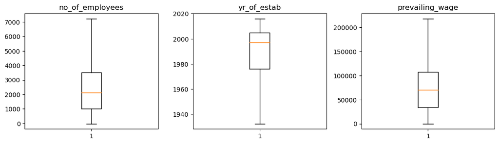

```python
numeric_columns = df_visa_filled.select_dtypes(include=np.number).columns.tolist()

plt.figure(figsize=(15, 12))

for i, variable in enumerate(numeric_columns):
    plt.subplot(4, 4, i + 1)
    plt.boxplot(df_visa_filled[variable], whis=1.5)
    plt.tight_layout()
    plt.title(variable)

plt.show()
```

- The whiskers now stop at a capped range, with no extreme dots/outliers beyond the upper end or at the lower end.

**Preparing data for modeling**

- Handle the string Object `continent`, `education_of_employee`, `has_job_experience`, `requires_job_training`, `region_of_employment`, `unit_of_wage`, `full_time_position` using panda `one hot encoding`
- Split the data into train and test to be able to evaluate the model that we build on the train data
- Based on the business problem, we need to predict '`case_status`', so this can be set to y.
- All other variables or aka `features` can be set to X

```python
# create a final copy of df_visa_filled. that way, we don't jeopradize the dataset
df_visa_final = df_visa_filled.copy()
```

```python
df_visa_final.head()
```

|  | continent | education_of_employee | has_job_experience | requires_job_training | no_of_employees | yr_of_estab | region_of_employment | prevailing_wage | unit_of_wage | full_time_position | case_status |
| --- | --- | --- | --- | --- | --- | --- | --- | --- | --- | --- | --- |
| 0 | Asia | High School | N | N | 7227 | 2007.0 | West | 592.2029 | Hour | Y | 0 |
| 1 | Asia | Master's | Y | N | 2412 | 2002.0 | Northeast | 83425.6500 | Year | Y | 1 |
| 2 | Asia | Bachelor's | N | Y | 7227 | 2008.0 | West | 122996.8600 | Year | Y | 0 |
| 3 | Asia | Bachelor's | N | N | 98 | 1932.5 | West | 83434.0300 | Year | Y | 0 |
| 4 | Africa | Master's | Y | N | 1082 | 2005.0 | South | 149907.3900 | Year | Y | 1 |

```python
# Creating X features to predict y variables
X = df_visa_final.drop(["case_status"], axis=1)
y = df_visa_final["case_status"]
```

```python
# Check X dtypes
X.info()
```

```
<class 'pandas.core.frame.DataFrame'>
RangeIndex: 25480 entries, 0 to 25479
Data columns (total 10 columns):
 #   Column                 Non-Null Count  Dtype
---  ------                 --------------  -----
 0   continent              25480 non-null  object
 1   education_of_employee  25480 non-null  object
 2   has_job_experience     25480 non-null  object
 3   requires_job_training  25480 non-null  object
 4   no_of_employees        25480 non-null  int64
 5   yr_of_estab            25480 non-null  float64
 6   region_of_employment   25480 non-null  object
 7   prevailing_wage        25480 non-null  float64
 8   unit_of_wage           25480 non-null  object
 9   full_time_position     25480 non-null  object
dtypes: float64(2), int64(1), object(7)
memory usage: 1.9+ MB
```

```python
# one hot coding using panda's dummies method
X = pd.get_dummies(
    X,
    columns=X.select_dtypes(include=["object", "category"]).columns.tolist(),
    drop_first=True
)
```

```python
X.head()
```

|  | no_of_employees | yr_of_estab | prevailing_wage | continent_Asia | continent_Europe | continent_North America | continent_Oceania | continent_South America | education_of_employee_Doctorate | education_of_employee_High School | education_of_employee_Master's | has_job_experience_Y | requires_job_training_Y | region_of_employment_Midwest | region_of_employment_Northeast | region_of_employment_South | region_of_employment_West | unit_of_wage_Month | unit_of_wage_Week | unit_of_wage_Year | full_time_position_Y |
| --- | --- | --- | --- | --- | --- | --- | --- | --- | --- | --- | --- | --- | --- | --- | --- | --- | --- | --- | --- | --- | --- |
| 0 | 7227 | 2007.0 | 592.2029 | True | False | False | False | False | False | True | False | False | False | False | False | False | True | False | False | False | True |
| 1 | 2412 | 2002.0 | 83425.6500 | True | False | False | False | False | False | False | True | True | False | False | True | False | False | False | False | True | True |
| 2 | 7227 | 2008.0 | 122996.8600 | True | False | False | False | False | False | False | False | False | True | False | False | False | True | False | False | True | True |
| 3 | 98 | 1932.5 | 83434.0300 | True | False | False | False | False | False | False | False | False | False | False | False | False | True | False | False | True | True |
| 4 | 1082 | 2005.0 | 149907.3900 | False | False | False | False | False | False | False | True | True | False | False | False | True | False | False | False | True | True |

```python
# converting the input attributes into float type for modeling
X = X.astype(float)
X.head()
```

|  | no_of_employees | yr_of_estab | prevailing_wage | continent_Asia | continent_Europe | continent_North America | continent_Oceania | continent_South America | education_of_employee_Doctorate | education_of_employee_High School | education_of_employee_Master's | has_job_experience_Y | requires_job_training_Y | region_of_employment_Midwest | region_of_employment_Northeast | region_of_employment_South | region_of_employment_West | unit_of_wage_Month | unit_of_wage_Week | unit_of_wage_Year | full_time_position_Y |
| --- | --- | --- | --- | --- | --- | --- | --- | --- | --- | --- | --- | --- | --- | --- | --- | --- | --- | --- | --- | --- | --- |
| 0 | 7227.0 | 2007.0 | 592.2029 | 1.0 | 0.0 | 0.0 | 0.0 | 0.0 | 0.0 | 1.0 | 0.0 | 0.0 | 0.0 | 0.0 | 0.0 | 0.0 | 1.0 | 0.0 | 0.0 | 0.0 | 1.0 |
| 1 | 2412.0 | 2002.0 | 83425.6500 | 1.0 | 0.0 | 0.0 | 0.0 | 0.0 | 0.0 | 0.0 | 1.0 | 1.0 | 0.0 | 0.0 | 1.0 | 0.0 | 0.0 | 0.0 | 0.0 | 1.0 | 1.0 |
| 2 | 7227.0 | 2008.0 | 122996.8600 | 1.0 | 0.0 | 0.0 | 0.0 | 0.0 | 0.0 | 0.0 | 0.0 | 0.0 | 1.0 | 0.0 | 0.0 | 0.0 | 1.0 | 0.0 | 0.0 | 1.0 | 1.0 |
| 3 | 98.0 | 1932.5 | 83434.0300 | 1.0 | 0.0 | 0.0 | 0.0 | 0.0 | 0.0 | 0.0 | 0.0 | 0.0 | 0.0 | 0.0 | 0.0 | 0.0 | 1.0 | 0.0 | 0.0 | 1.0 | 1.0 |
| 4 | 1082.0 | 2005.0 | 149907.3900 | 0.0 | 0.0 | 0.0 | 0.0 | 0.0 | 0.0 | 0.0 | 1.0 | 1.0 | 0.0 | 0.0 | 0.0 | 1.0 | 0.0 | 0.0 | 0.0 | 1.0 | 1.0 |

**EDA** - It is a good idea to explore the data once again after manipulating it.

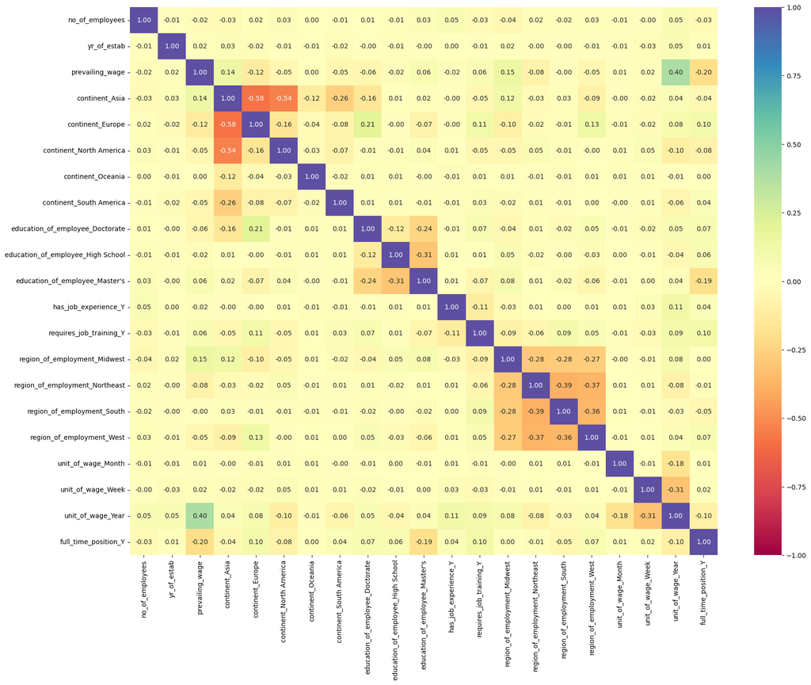

```python
# create heatmap to understand correlation strength between all the X variables
num_cols = X.select_dtypes(include=np.number).columns.tolist()

plt.figure(figsize=(20, 15))
ax = sns.heatmap(X[num_cols].corr(), annot=True, vmin=-1, vmax=1, fmt=".2f", cmap="Spectral")
plt.show()
```

# **Model Building**

```python
X.shape
```

```
(25480, 21)
```

```python
# Splitting data into training, validation and test set:
# first we split data into 2 parts, say temporary and test

X_temp, X_test, y_temp, y_test = train_test_split(
    X, y, test_size=0.2, random_state=1, stratify=y
)

# then we split the temporary set into train and validation

X_train, X_val, y_train, y_val = train_test_split(
    X_temp, y_temp, test_size=0.25, random_state=1, stratify=y_temp
)
```

```python
print("Shape of Training set : ", X_train.shape)
print("=============================================")
print("Shape of the Validation set: ", X_val.shape)
print("=============================================")
print("Shape of test set : ", X_test.shape)
print("=============================================")
print("Percentage of classes in training set:")
print("=============================================")
print(y_train.value_counts(normalize=True))
print("Percentage of classes in validation set:")
print("=============================================")
print(y_val.value_counts(normalize=True))
print("Percentage of classes in test set:")
print("=============================================")
print(y_test.value_counts(normalize=True))
print("=============================================")
```

```
Shape of Training set :  (15288, 21)
=============================================
Shape of the Validation set:  (5096, 21)
=============================================
Shape of test set :  (5096, 21)
=============================================
Percentage of classes in training set:
=============================================
case_status
1    0.667844
0    0.332156
Name: proportion, dtype: float64
Percentage of classes in validation set:
=============================================
case_status
1    0.667975
0    0.332025
Name: proportion, dtype: float64
Percentage of classes in test set:
=============================================
case_status
1    0.667975
0    0.332025
Name: proportion, dtype: float64
=============================================
```

## Model evaluation criterion

### Understanding Wrong Predictions in Visa Approval Modeling

When our model predicts whether a visa application will be **Certified** or **Denied**, it can make two types of incorrect predictions:

1. **False Positive (Type I Error)**
   - The model predicts: Certified
   - Reality: Denied
   - Risk: A visa is wrongly approved.
2. **False Negative (Type II Error)**
   - The model predicts: Denied
   - Reality: Certified
   - Risk: A qualified person is wrongly rejected, and the U.S. loses a skilled worker who could contribute to the economy.

### Which Case Is More Important?

**Both** types of errors are important:

- Certifying someone who should be denied takes away job opportunities from eligible local workers.
- Denying someone who should be certified leads to losing valuable international talent.

### How Do We Reduce These Errors?

To ensure our model performs well across both classes (Certified and Denied), we:

1. **Use F1 Score for Evaluation**
   - Accuracy can be misleading when classes are imbalanced.
   - F1 Score balances **Precision** and **Recall**:
     - **Precision**: Out of predicted Certified cases, how many were actually Certified?
     - **Recall**: Out of all actual Certified cases, how many did the model correctly identify?
   - The **F1 Score** is the **harmonic mean** of precision and recall, which ensures the model isn’t performing well in just one and poorly in the other.
2. **Apply Balanced Class Weights**
   - This tells the model to give equal attention to both Certified and Denied cases, even if one class appears much more frequently than the other.

Using the F1 Score and balanced class weights helps us **minimize the impact of both false positives and false negatives**, making the model fairer and more effective.

```python
# Lets create method to calculare model performancce
# Accuracy, Precision, Recall and F1-score

def model_performance_metrics(
    model, predictors, target
):
    """
    Function to compute different metrics to check classification model performance

    model: classifier
    predictors: independent variables
    target: dependent variable
    """

    # checking which probabilities are greater than threshold
    pred_temp = model.predict(predictors)
    # rounding off the above values to get classes
    pred = np.round(pred_temp)

    acc = accuracy_score(target, pred)  # to compute Accuracy
    recall = recall_score(target, pred)  # to compute Recall
    precision = precision_score(target, pred)  # to compute Precision
    f1 = f1_score(target, pred)  # to compute F1-score

    # creating a dataframe of metrics
    df_perf = pd.DataFrame(
        {"Accuracy": acc, "Recall": recall, "Precision": precision, "F1": f1,},
        index=[0],
    )
    return df_perf
```

```python
def calculate_confusion_matrix(model, predictors, target):

    """
    To plot the confusion_matrix with percentages

    model: classifier
    predictors: independent variables
    target: dependent variable
    """
    y_pred = model.predict(predictors)
    cm = confusion_matrix(target, y_pred)

    # Labels: TN, FP, FN, TP with count and % format
    labels = np.asarray(
        [
            ["True Negative\n{0}\n{1:.2%}".format(cm[0, 0], cm[0, 0] / cm.sum()),
             "False Positive\n{0}\n{1:.2%}".format(cm[0, 1], cm[0, 1] / cm.sum())],
            ["False Negative\n{0}\n{1:.2%}".format(cm[1, 0], cm[1, 0] / cm.sum()),
             "True Positive\n{0}\n{1:.2%}".format(cm[1, 1], cm[1, 1] / cm.sum())]
        ]
    )

    # Plot
    fig, ax = plt.subplots(figsize=(6, 4))
    for i in range(2):
        for j in range(2):
            ax.add_patch(plt.Rectangle((j, i), 1, 1, fill=False, edgecolor='black', lw=2))
            ax.text(j + 0.5, i + 0.5, labels[i, j],
                    ha="center", va="center", fontsize=12, color="black")

    # Add outer border around entire matrix
    ax.add_patch(plt.Rectangle((0, 0), 2, 2, fill=False, edgecolor='black', lw=3))

    # Axes formatting
    ax.set_xticks([0.5, 1.5])
    ax.set_xticklabels(["Pred: 0", "Pred: 1"])
    ax.set_yticks([0.5, 1.5])
    ax.set_yticklabels(["True: 0", "True: 1"])
    ax.invert_yaxis()
    ax.set_xlim(0, 2)
    ax.set_ylim(0, 2)
    ax.set_title("Confusion Matrix", fontsize=14)
    plt.grid(False)
    plt.tight_layout()
    plt.show()
```

## Model Building - Original Data

```python
# Function to evaluate and collect performance
def evaluate_models_on_given_data(models, X_eval, y_eval):
    """Evaluate pre-trained models on a given dataset (e.g. validation/test)"""
    performance = {}
    for name, model in models.items():
        df = model_performance_metrics(model, X_eval, y_eval)
        performance[name] = df.iloc[0]
    return pd.DataFrame(performance).T
```

```python
# Defining, Instantiating all the  models and fitting the models to X_train, y_train
original_models  = {
    "Bagging": BaggingClassifier(random_state=1),
    "Random Forest": RandomForestClassifier(random_state=1, class_weight="balanced"),
    "AdaBoost": AdaBoostClassifier(random_state=1),
    "Gradient Boosting": GradientBoostingClassifier(random_state=1),
    "XGBoost": XGBClassifier(random_state=1, eval_metric='logloss')
}

for name, model in original_models.items():
    model.fit(X_train, y_train)
```

```python
# Training performance (optional, for both)
original_data_train_perf_df = evaluate_models_on_given_data(original_models, X_train, y_train)

# Validation performance (this is the key part!)
original_data_val_perf_df = evaluate_models_on_given_data(original_models, X_val, y_val)
```

```python
# # Display the summary tables
print("===============================================")
print("ORIGINAL DATA Training Performance Comparison  ")
print("===============================================")
display(original_data_train_perf_df)

print("===============================================")
print("ORIGINAL DATA Validation Performance Comparison")
print("===============================================")
display(original_data_val_perf_df)
```

```
===============================================
ORIGINAL DATA Training Performance Comparison
===============================================
```

|  | Accuracy | Recall | Precision | F1 |
| --- | --- | --- | --- | --- |
| Bagging | 0.984563 | 0.986288 | 0.990557 | 0.988418 |
| Random Forest | 1.000000 | 1.000000 | 1.000000 | 1.000000 |
| AdaBoost | 0.740123 | 0.889324 | 0.761553 | 0.820494 |
| Gradient Boosting | 0.757261 | 0.878942 | 0.783824 | 0.828662 |
| XGBoost | 0.858189 | 0.944074 | 0.857868 | 0.898909 |

```
===============================================
ORIGINAL DATA Validation Performance Comparison
===============================================
```

|  | Accuracy | Recall | Precision | F1 |
| --- | --- | --- | --- | --- |
| Bagging | 0.697998 | 0.770270 | 0.775969 | 0.773109 |
| Random Forest | 0.726452 | 0.839894 | 0.771036 | 0.803993 |
| AdaBoost | 0.736460 | 0.879553 | 0.762414 | 0.816805 |
| Gradient Boosting | 0.753532 | 0.871622 | 0.783677 | 0.825313 |
| XGBoost | 0.726648 | 0.848707 | 0.766923 | 0.805745 |

**Observaton**

## Model Evaluation Summary

To compare different classification models for predicting visa approval status, I evaluated five ensemble methods using four key metrics: **Accuracy**, **Recall**, **Precision**, and **F1 Score** and computed these metrics on both the **training** and **validation** datasets.

### Observations from Validation Performance:

- **Bagging** showed an F1 score of ~0.77 on validation (vs. ~0.99 on training), indicating **moderate overfitting**, but still decent generalization.
- **Random Forest** dropped from a perfect F1 of 1.0 on training to ~0.80 on validation — this suggests **strong overfitting**, despite acceptable validation performance.
- **AdaBoost** and **Gradient Boosting** had very similar F1 scores on both training and validation (~0.82), which indicates they are **generalizing well** and are less prone to overfitting.
- **XGBoost** had a validation F1 of ~0.81 (vs. ~0.90 on training), showing **some overfitting**, but it still maintained strong performance.

## Model Building - Oversampled Data

```python
print("Shape of Training set : ", X_train.shape)
print("=============================================")
print("Shape of the Validation set: ", X_val.shape)
print("=============================================")
print("Shape of test set : ", X_test.shape)
print("=============================================")
print("Percentage of classes in training set:")
print("=============================================")
print(y_train.value_counts(normalize=True))
print("Percentage of classes in validation set:")
print("=============================================")
print(y_val.value_counts(normalize=True))
print("Percentage of classes in test set:")
print("=============================================")
print(y_test.value_counts(normalize=True))
print("=============================================")
```

```
Shape of Training set :  (15288, 21)
=============================================
Shape of the Validation set:  (5096, 21)
=============================================
Shape of test set :  (5096, 21)
=============================================
Percentage of classes in training set:
=============================================
case_status
1    0.667844
0    0.332156
Name: proportion, dtype: float64
Percentage of classes in validation set:
=============================================
case_status
1    0.667975
0    0.332025
Name: proportion, dtype: float64
Percentage of classes in test set:
=============================================
case_status
1    0.667975
0    0.332025
Name: proportion, dtype: float64
=============================================
```

**Observation**

- class distribution is somewhat imbalanced, but not severely.
- Lean toward predicting "Certified" more often
- Appear to have high accuracy, while failing on the "Denied" cases (the minority class)

## Model Building - Oversampled Data

**I am creating `X_train_over` and `y_train_over` dataset using SMOTE function and trying to balance the class a.k.a `case_status`**

```python
print(f"Before Oversampling:")
print(f"  Certified count: {sum(y_train == 1)}")
print(f"  Denied count:    {sum(y_train == 0)}\n")

# Apply SMOTE

# sampling_strategy=1:
#   This sets the ratio of minority to majority class after resampling.
#   A value of 1 means the minority class will be oversampled to match the majority class exactly (1:1 ratio).

# k_neighbors=5:
#   This defines the number of nearest neighbors used to generate synthetic samples.
#   For each minority class sample, SMOTE finds its 5 nearest neighbors and creates new points between them.

# random_state=1:
#   Sets the seed for random number generation to ensure reproducibility.
#   Using the same seed means you'll get the same resampling results each time you run the code.

sm = SMOTE(sampling_strategy=1, k_neighbors=5, random_state=1)
X_train_over_sampled_data, y_train_over_sampled_data = sm.fit_resample(X_train, y_train)

# After Oversampling
print(f"After Oversampling:")
print(f"  Certified count: {sum(y_train_over_sampled_data == 1)}")
print(f"  Denied count:    {sum(y_train_over_sampled_data == 0)}")
print(f"  X shape:         {X_train_over_sampled_data.shape}")
print(f"  y shape:         {y_train_over_sampled_data.shape}\n")
```

```
Before Oversampling:
  Certified count: 10210
  Denied count:    5078

After Oversampling:
  Certified count: 10210
  Denied count:    10210
  X shape:         (20420, 21)
  y shape:         (20420,)
```

**Instantiate set of models and check performance on `X_train_over_sampled_data` and `y_train_over_sampled_data`**

```python
# Defining, Instantiating all the  models and fitting the models to X_train_over_sampled_data, y_train_over_sampled_data

over_sampled_data_models = {
    "Bagging": BaggingClassifier(random_state=1),
    "Random Forest": RandomForestClassifier(random_state=1, class_weight="balanced"),
    "AdaBoost": AdaBoostClassifier(random_state=1),
    "Gradient Boosting": GradientBoostingClassifier(random_state=1),
    "XGBoost": XGBClassifier(random_state=1, eval_metric='logloss')
}

for name, model in over_sampled_data_models.items():
    model.fit(X_train_over_sampled_data, y_train_over_sampled_data)
```

```python
# Training performance
over_sampled_data_train_perf_df = evaluate_models_on_given_data(over_sampled_data_models, X_train_over_sampled_data, y_train_over_sampled_data)

# Validation performance (this is the key part!)
over_sampled_val_perf_df = evaluate_models_on_given_data(over_sampled_data_models, X_val, y_val)
```

```python
# Display the summary tables
print("======================================================")
print("OVER SAMPLING DATA - Training Performance Comparison  ")
print("======================================================")
display(over_sampled_data_train_perf_df)

print("======================================================")
print("OVER SAMPLING DATA - Validation Performance Comparison")
print("======================================================")
display(over_sampled_val_perf_df)
```

```
======================================================
OVER SAMPLING DATA - Training Performance Comparison
======================================================
```

|  | Accuracy | Recall | Precision | F1 |
| --- | --- | --- | --- | --- |
| Bagging | 0.988100 | 0.985309 | 0.990840 | 0.988067 |
| Random Forest | 0.999951 | 1.000000 | 0.999902 | 0.999951 |
| AdaBoost | 0.799070 | 0.857297 | 0.767874 | 0.810125 |
| Gradient Boosting | 0.814300 | 0.863761 | 0.786007 | 0.823052 |
| XGBoost | 0.881685 | 0.930460 | 0.847760 | 0.887187 |

```
======================================================
OVER SAMPLING DATA - Validation Performance Comparison
======================================================
```

|  | Accuracy | Recall | Precision | F1 |
| --- | --- | --- | --- | --- |
| Bagging | 0.696625 | 0.764982 | 0.777313 | 0.771099 |
| Random Forest | 0.724097 | 0.827556 | 0.774752 | 0.800284 |
| AdaBoost | 0.731358 | 0.846063 | 0.773154 | 0.807967 |
| Gradient Boosting | 0.752551 | 0.854877 | 0.791406 | 0.821918 |
| XGBoost | 0.731947 | 0.851351 | 0.771155 | 0.809271 |

### Observation: Original Data vs SMOTE (Oversampled Data)

I compared the F1 scores of five ensemble models trained on:

- **Original training data**
- **SMOTE oversampled training data**

Below is a summary of **`validation`** F1 scores:

| Model | Original Val F1 | SMOTE Val F1 | Change | Inference |
| --- | --- | --- | --- | --- |
| **Bagging** | 0.7731 | 0.7711 | ~0.002 | No gain from SMOTE; already generalizes well |
| **Random Forest** | 0.8039 | 0.8002 | ~0.004 | Slight drop; still overfitting on training (F1 = 1.0) |
| **AdaBoost** | 0.8168 | 0.8079 | ~0.009 | Minor drop; well-balanced either way |
| **Gradient Boosting** | 0.8253 | 0.8219 | ~0.003 | Minimal change; strong generalization in both cases |
| **XGBoost** | 0.8057 | 0.8093 | ~0.004 | Slight improvement with SMOTE; benefits from class balance |

### Key Takeaways:

- **SMOTE did not significantly improve** model performance overall, but did not hurt either.
- **XGBoost** was the only model to show a slight improvement in validation F1.
- **Random Forest** remains highly overfit (perfect training scores), even after SMOTE.
- Boosting models (AdaBoost, Gradient Boosting, XGBoost) show the most **stable generalization** across both datasets.
- Focus moving forward should be on **hyperparameter tuning** (e.g., `max_depth`, `n_estimators`) rather than further resampling.

## Model Building - Undersampled Data

### Undersampling the Training Data

We use `RandomUnderSampler` from `imblearn` to handle class imbalance by **reducing the size of the majority class**.

- The `fit_resample()` method creates a **new training set** where the number of samples from each class is equal.
- This helps avoid model bias toward the majority class.
- Unlike SMOTE (which adds data), undersampling **removes real data**, so it’s best used when the dataset is large enough.

```python
# Instantiate RandomUnderSampler from imblearn
r_u_s = RandomUnderSampler(random_state=1)
X_train_under_sampled_data, y_train_under_sampled_data = r_u_s.fit_resample(X_train, y_train)
```

```python
# Class distribution before and after undersampling
print("Before Undersampling:")
print(f"  Certified count: {sum(y_train == 1)}")
print(f"  Denied count:    {sum(y_train == 0)}\n")

print("After Undersampling:")
print(f"  Certified count: {sum(y_train_under_sampled_data == 1)}")
print(f"  Denied count:    {sum(y_train_under_sampled_data == 0)}")
print(f"  X shape:         {X_train_under_sampled_data.shape}")
print(f"  y shape:         {y_train_under_sampled_data.shape}\n")
```

```
Before Undersampling:
  Certified count: 10210
  Denied count:    5078

After Undersampling:
  Certified count: 5078
  Denied count:    5078
  X shape:         (10156, 21)
  y shape:         (10156,)
```

**Observation**

- The dataset is now balanced after applying random undersampling. The majority class has been reduced to match the size of the minority class, effectively addressing the class imbalance issue.

**Instantiate set of models and check performance on `X_train_under_sampled_data` and `y_train_under_sampled_data`**

```python
# Defining, Instantiating all the  models and fitting the models to X_train_over_sampled_data, y_train_over_sampled_data

under_sampled_data_models = {
    "Bagging": BaggingClassifier(random_state=1),
    "Random Forest": RandomForestClassifier(random_state=1, class_weight="balanced"),
    "AdaBoost": AdaBoostClassifier(random_state=1),
    "Gradient Boosting": GradientBoostingClassifier(random_state=1),
    "XGBoost": XGBClassifier(random_state=1, eval_metric='logloss')
}

for name, model in under_sampled_data_models.items():
    model.fit(X_train_under_sampled_data, y_train_under_sampled_data)
```

```python
# Training performance
under_sampled_data_train_perf_df = evaluate_models_on_given_data(under_sampled_data_models, X_train_under_sampled_data, y_train_under_sampled_data)

# Validation performance (this is the key part!)
under_sampled_val_perf_df = evaluate_models_on_given_data(under_sampled_data_models, X_val, y_val)
```

```python
# Display the summary tables
print("========================================================")
print("UNDER SAMPLING DATA - Training Performance Comparison   ")
print("========================================================")
display(under_sampled_data_train_perf_df)

print("========================================================")
print("UNDER SAMPLING DATA - Validation Performance Comparison ")
print("========================================================")
display(under_sampled_val_perf_df)
```

```
========================================================
UNDER SAMPLING DATA - Training Performance Comparison
========================================================
```

|  | Accuracy | Recall | Precision | F1 |
| --- | --- | --- | --- | --- |
| Bagging | 0.980110 | 0.968885 | 0.991136 | 0.979884 |
| Random Forest | 1.000000 | 1.000000 | 1.000000 | 1.000000 |
| AdaBoost | 0.696633 | 0.712288 | 0.690663 | 0.701309 |
| Gradient Boosting | 0.719870 | 0.746751 | 0.708653 | 0.727203 |
| XGBoost | 0.878102 | 0.887948 | 0.870800 | 0.879290 |

```
========================================================
UNDER SAMPLING DATA - Validation Performance Comparison
========================================================
```

|  | Accuracy | Recall | Precision | F1 |
| --- | --- | --- | --- | --- |
| Bagging | 0.651688 | 0.606639 | 0.825670 | 0.699407 |
| Random Forest | 0.689168 | 0.678907 | 0.824768 | 0.744763 |
| AdaBoost | 0.703689 | 0.709753 | 0.822328 | 0.761905 |
| Gradient Boosting | 0.722135 | 0.734136 | 0.830233 | 0.779233 |
| XGBoost | 0.687794 | 0.683020 | 0.819528 | 0.745073 |

### Validation F1 Score Comparison: Original Data vs Undersampled Data

I compare the validation F1 scores of ensemble models trained on:

- **Original training data**
- **Random undersampled training data**

| Model | Original F1 | Undersampled F1 | Change | Inference |
| --- | --- | --- | --- | --- |
| **Bagging** | 0.7731 | 0.6994 | ~0.0737 | Significant drop — likely hurt by loss of majority class diversity |
| **Random Forest** | 0.8039 | 0.7448 | ~0.0591 | Still solid, but reduced generalization due to fewer examples |
| **AdaBoost** | 0.8168 | 0.7619 | ~0.0549 | Mild impact — relatively stable performance |
| **Gradient Boost** | 0.8253 | 0.7792 | ~0.0461 | Decline — still robust generalization |
| **XGBoost** | 0.8057 | 0.7451 | ~0.0606 | Consistent drop — reduced data may limit learning |

# **Model Performance Improvement**

## **Note**

1. Sample parameter grids have been provided to do necessary hyperparameter tuning. These sample grids are expected to provide a balance between model performance improvement and execution time. One can extend/reduce the parameter grid based on execution time and system configuration.
- Please note that if the parameter grid is extended to improve the model performance further, the execution time will increase
2. The models chosen in this notebook are based on test runs. One can update the best models as obtained upon code execution and tune them for best performance.
- For Gradient Boosting:

```
param_grid = {
    "init": [AdaBoostClassifier(random_state=1),DecisionTreeClassifier(random_state=1)],
    "n_estimators": np.arange(50,110,25),
    "learning_rate": [0.01,0.1,0.05],
    "subsample":[0.7,0.9],
    "max_features":[0.5,0.7,1],
}
```

- For Adaboost:

```
param_grid = {
    "n_estimators": np.arange(50,110,25),
    "learning_rate": [0.01,0.1,0.05],
    "base_estimator": [
        DecisionTreeClassifier(max_depth=2, random_state=1),
        DecisionTreeClassifier(max_depth=3, random_state=1),
    ],
}
```

- For Bagging Classifier:

```
param_grid = {
    'max_samples': [0.8,0.9,1],
    'max_features': [0.7,0.8,0.9],
    'n_estimators' : [30,50,70],
}
```

- For Random Forest:

```
param_grid = {
    "n_estimators": [50,110,25],
    "min_samples_leaf": np.arange(1, 4),
    "max_features": [np.arange(0.3, 0.6, 0.1),'sqrt'],
    "max_samples": np.arange(0.4, 0.7, 0.1)
}
```

- For Decision Trees:

```
param_grid = {
    'max_depth': np.arange(2,6),
    'min_samples_leaf': [1, 4, 7],
    'max_leaf_nodes' : [10, 15],
    'min_impurity_decrease': [0.0001,0.001]
}
```

- For XGBoost:

```
param_grid={'n_estimators':np.arange(50,110,25),
            'scale_pos_weight':[1,2,5],
            'learning_rate':[0.01,0.1,0.05],
            'gamma':[1,3],
            'subsample':[0.7,0.9]
}
```

## Hyperparameter Tuning - Random Forest

```python
%%time
# measures the execution time of the entire code cell

# random_state=1: ensures reproducibility
# oob_score=True: enables out-of-bag score estimation (an internal validation score, like cross-validation)
# uses bootstrapped samples to train individual trees (standard in RF).

rfc_tuned = RandomForestClassifier(random_state=1, oob_score=True, bootstrap=True)

# searching over 2×2×3×3 = 36 combinations of parameters

parameters = {
    "max_depth": list(np.arange(5, 15, 5)), # [5, 10]
    "max_features": ["sqrt", "log2"], # number of features to consider at each split
    "min_samples_split": [3, 5, 7], # minimum samples required to split a node
    "n_estimators": np.arange(10, 40, 10), # number of trees: [10, 20, 30]
}

# Type of scoring used to compare parameter combinations
# custom scoring function that GridSearchCV can use to evaluate each combination of hyperparameters
# using F1 score instead of default accuracy
# to balance precision and recall, ideal for imbalanced datasets.
acc_scorer = metrics.make_scorer(metrics.f1_score)

# Run the grid search

#exhaustive search over all combinations in parameters.
# 5-fold cross-validation for each combination
#n_jobs=-1 runs it in parallel for speed

grid_obj = GridSearchCV(rfc_tuned, parameters, scoring=acc_scorer, cv=5, n_jobs=-1)

#Fits the grid search using the oversampled training data
grid_obj = grid_obj.fit(X_train_over_sampled_data, y_train_over_sampled_data)


# Set the clf to the best combination of parameters
rfc_tuned = grid_obj.best_estimator_ # Extracts the best-performing model from the grid search.

# Fit the best algorithm to the data.

# it re-trains the best model on the original training data
# To generalize on natural distributions again.
rfc_tuned.fit(X_train, y_train)
```

```
CPU times: total: 20.7 s
Wall time: 1min 59s
```

```
RandomForestClassifier(max_depth=10, min_samples_split=7, n_estimators=30,
                       oob_score=True, random_state=1)
```

### Checking model performance on training set

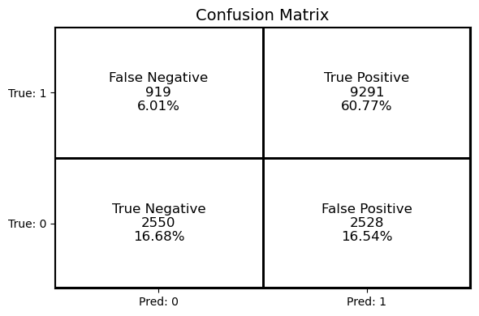

```python
calculate_confusion_matrix(rfc_tuned, X_train, y_train)
```

```python
rfc_tuned_model_train_perf = model_performance_metrics(
    rfc_tuned, X_train, y_train
)
rfc_tuned_model_train_perf
```

|  | Accuracy | Recall | Precision | F1 |
| --- | --- | --- | --- | --- |
| 0 | 0.774529 | 0.90999 | 0.786107 | 0.843524 |

### Checking model performance on validation set

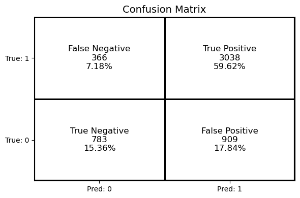

```python
calculate_confusion_matrix(rfc_tuned, X_val, y_val)
```

```python
rfc_tuned_model_val_perf = model_performance_metrics(
    rfc_tuned, X_val, y_val
)
rfc_tuned_model_val_perf
```

|  | Accuracy | Recall | Precision | F1 |
| --- | --- | --- | --- | --- |
| 0 | 0.749804 | 0.892479 | 0.769699 | 0.826554 |

### Evaluation Summary: Tuned Random Forest Performance

| Dataset | Accuracy | Recall | Precision | F1 Score |
| --- | --- | --- | --- | --- |
| **Training** | 0.7745 | 0.9100 | 0.7861 | 0.8435 |
| **Validation** | 0.7498 | 0.8925 | 0.7697 | 0.8266 |

### Key Observations:

- **Minimal drop in F1 score** from training to validation (only ~2%) indicates the model is **generalizing well** and is not overfitting.
- **High recall** on both training (0.91) and validation (0.89) shows the model is highly effective at detecting the positive class (e.g., "Certified" visa cases).  
  → This is important in applications where **missing a true positive is costly**.
- **Precision is slightly lower than recall**, but still strong — suggesting some false positives, but within a reasonable margin.  
  → This trade-off is acceptable when recall is more critical.
- **Accuracy is lower than F1**, which often happens in imbalanced datasets.  
  → Reinforces that **F1 is the more appropriate metric** to evaluate performance in this context.

### Summary:

> The tuned `RandomForestClassifier` is performing robustly, with excellent generalization, strong recall, and balanced precision.  
> This makes it a reliable model choice for imbalanced classification tasks like visa approval prediction.

## Hyperparameter Tuning - AdaBoost Classifier

```python
%%time
# measures the execution time of the entire code cell

# random_state=1: ensures reproducibility
abc_tuned = AdaBoostClassifier(random_state=1)

# searching over 2×3×3 = 18 combinations of parameters

parameters = {
    # Let's try different max_depth for base_estimator
    "estimator": [
        DecisionTreeClassifier(max_depth=2, random_state=1),
        DecisionTreeClassifier(max_depth=3, random_state=1),
    ],
    "n_estimators": np.arange(50,110,25),
    "learning_rate": np.arange(0.01,0.1,0.05),
}

# Type of scoring used to compare parameter combinations
# custom scoring function that GridSearchCV can use to evaluate each combination of hyperparameters
# using F1 score instead of default accuracy
# to balance precision and recall, ideal for imbalanced datasets.
acc_scorer = metrics.make_scorer(metrics.f1_score)

# Run the grid search

#exhaustive search over all combinations in parameters.
# 5-fold cross-validation for each combination
#n_jobs=-1 runs it in parallel for speed

grid_obj = GridSearchCV(abc_tuned, parameters, scoring=acc_scorer, cv=5, n_jobs=-1)

#Fits the grid search using the oversampled training data
grid_obj = grid_obj.fit(X_train, y_train)


# Set the clf to the best combination of parameters
abc_tuned = grid_obj.best_estimator_ # Extracts the best-performing model from the grid search.

# Fit the best algorithm to the data.

# it re-trains the best model on the original training data
# To generalize on natural distributions again.
abc_tuned.fit(X_train, y_train)
```

```
CPU times: total: 13.3 s
Wall time: 1min 33s
```

```
AdaBoostClassifier(estimator=DecisionTreeClassifier(max_depth=3,
                                                    random_state=1),
                   learning_rate=0.060000000000000005, n_estimators=100,
                   random_state=1)
```

### Checking model performance on training set

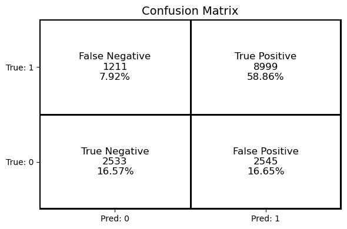

```python
calculate_confusion_matrix(abc_tuned, X_train, y_train)
```

```python
abc_tuned_model_train_perf = model_performance_metrics(
    abc_tuned, X_train, y_train
)
abc_tuned_model_train_perf
```

|  | Accuracy | Recall | Precision | F1 |
| --- | --- | --- | --- | --- |
| 0 | 0.754317 | 0.881391 | 0.779539 | 0.827342 |

### Checking model performance on validation set

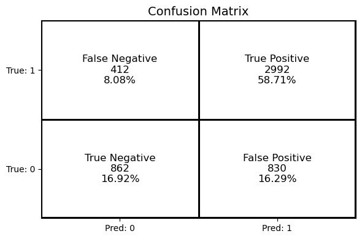

```python
calculate_confusion_matrix(abc_tuned, X_val, y_val)
```

```python
abc_tuned_model_val_perf = model_performance_metrics(
    abc_tuned, X_val, y_val
)
abc_tuned_model_val_perf
```

|  | Accuracy | Recall | Precision | F1 |
| --- | --- | --- | --- | --- |
| 0 | 0.756279 | 0.878966 | 0.782836 | 0.828121 |

### Evaluation Summary: Tuned AdaBoost Performance

| Dataset | Accuracy | Recall | Precision | F1 Score |
| --- | --- | --- | --- | --- |
| **Training** | 0.7543 | 0.8814 | 0.7795 | 0.8273 |
| **Validation** | 0.7563 | 0.8790 | 0.7828 | 0.8281 |

### Key Observations:

- **F1 score is consistent** across training (0.8273) and validation (0.8281), showing that the model is **generalizing very well** with no overfitting.
- **High recall** in both training and validation (~88%) indicates the model is doing a strong job at correctly identifying the positive class (e.g. “Certified” cases).
- **Precision is also solid** (~78%) — meaning the model isn’t just casting a wide net, but making accurate positive predictions as well.
- **Accuracy ≈ 75%** is expected given the class imbalance (~70% Certified), but we focus more on **F1 score** due to its ability to balance class-wise performance.

### Summary:

> The tuned **AdaBoostClassifier**, trained on the original (imbalanced) dataset, shows strong performance with high and stable F1 scores.  
> It generalizes well, handles the imbalance effectively, and offers a great balance of **recall and precision** — making it a reliable model for this classification task.

## Hyperparameter Tuning - Gradient Boosting Classifier

```python
%%time
# measures the execution time of the entire code cell

# random_state=1: ensures reproducibility
# Choose the type of classifier.
gbc_tuned = GradientBoostingClassifier(
    init=AdaBoostClassifier(random_state=1), random_state=1
)

# searching over 3x2×4×3 = 72 combinations of parameters

# Grid of parameters to choose from
parameters = {
    "n_estimators": np.arange(50,110,25),
    "subsample": [0.7,0.9],
    "max_features": [0.7, 0.8, 0.9, 1],
    "learning_rate": [0.01,0.1,0.05],
}

# Type of scoring used to compare parameter combinations
# custom scoring function that GridSearchCV can use to evaluate each combination of hyperparameters
# using F1 score instead of default accuracy
# to balance precision and recall, ideal for imbalanced datasets.
acc_scorer = metrics.make_scorer(metrics.f1_score)

# Run the grid search

#exhaustive search over all combinations in parameters.
# 5-fold cross-validation for each combination
#n_jobs=-1 runs it in parallel for speed

grid_obj = GridSearchCV(gbc_tuned, parameters, scoring=acc_scorer, cv=5, n_jobs=-1)

#Fits the grid search using the oversampled training data
grid_obj = grid_obj.fit(X_train, y_train)


# Set the clf to the best combination of parameters
gbc_tuned = grid_obj.best_estimator_ # Extracts the best-performing model from the grid search.

# Fit the best algorithm to the data.

# it re-trains the best model on the original training data
# To generalize on natural distributions again.
gbc_tuned.fit(X_train, y_train)
```

```
CPU times: total: 30.2 s
Wall time: 7min 57s
```

```
GradientBoostingClassifier(init=AdaBoostClassifier(random_state=1),
                           learning_rate=0.05, max_features=0.9, random_state=1,
                           subsample=0.9)
```

### Checking model performance on training set

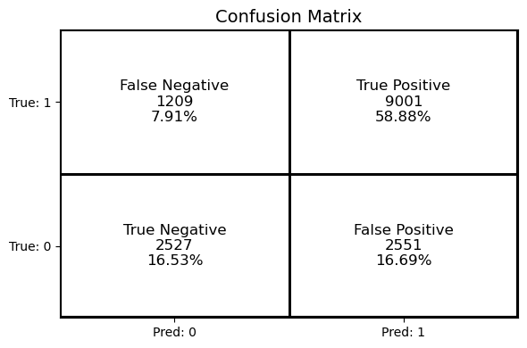

```python
calculate_confusion_matrix(gbc_tuned, X_train, y_train)
```

```python
gbc_tuned_model_train_perf = model_performance_metrics(
    gbc_tuned, X_train, y_train
)
gbc_tuned_model_train_perf
```

|  | Accuracy | Recall | Precision | F1 |
| --- | --- | --- | --- | --- |
| 0 | 0.754055 | 0.881587 | 0.779172 | 0.827222 |

### Checking model performance on validation set

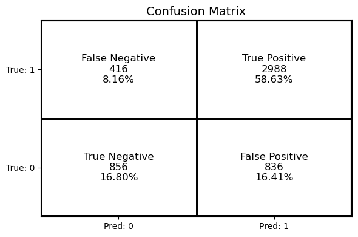

```python
calculate_confusion_matrix(gbc_tuned, X_val, y_val)
```

```python
gbc_tuned_model_val_perf = model_performance_metrics(
    gbc_tuned, X_val, y_val
)
gbc_tuned_model_val_perf
```

|  | Accuracy | Recall | Precision | F1 |
| --- | --- | --- | --- | --- |
| 0 | 0.754317 | 0.877791 | 0.781381 | 0.826785 |

### Evaluation Summary: Tuned Gradient Boosting Performance

| Dataset | Accuracy | Recall | Precision | F1 Score |
| --- | --- | --- | --- | --- |
| **Training** | 0.7541 | 0.8816 | 0.7792 | 0.8272 |
| **Validation** | 0.7543 | 0.8778 | 0.7814 | 0.8267 |

### Key Observations:

- **F1 Score** is nearly identical between training (0.8272) and validation (0.8267), indicating **excellent generalization** and minimal overfitting.
- **High recall** in both datasets (~88%) shows the model is very good at correctly identifying the positive class (“Certified” cases).  
  → This is crucial when minimizing false negatives is a priority.
- **Precision is consistent** (~78%) across both sets, suggesting the model also avoids too many false positives — a strong balance.
- **Accuracy is stable** at ~75%, but as with imbalanced data, **F1 remains the more meaningful metric** for evaluation.

### Summary:

> The tuned **GradientBoostingClassifier** demonstrates strong, consistent performance on both training and validation data.  
> With excellent F1 score stability and high recall, it is a reliable choice for this classification task — especially when class balance and minority class detection are critical.